# MovieLens Project Question Notebook

### `Project - MovieLens Data Analysis`

The GroupLens Research Project is a research group in the Department of Computer Science and Engineering at the University of Minnesota. The data is widely used for collaborative filtering and other filtering solutions. However, we will be using this data to act as a means to demonstrate our skill in using Python to “play” with data.

### `Objective:`

- To implement the techniques learnt as a part of the course.

### `Datasets Information:`

*rating.csv:* It contains information on ratings given by the users to a particular movie.

- user id: id assigned to every user
- movie id: id assigned to every movie
- rating: rating given by the user
- timestamp: Time recorded when the user gave a rating

*movie.csv:* File contains information related to the movies and their genre.

- movie id: id assigned to every movie
- movie title: Title of the movie
- release date: Date of release of the movie
- Action: Genre containing binary values (1 - for action 0 - not action)
- Adventure: Genre containing binary values (1 - for adventure 0 - not adventure)
- Animation: Genre containing binary values (1 - for animation 0 - not animation)
- Children’s: Genre containing binary values (1 - for children's 0 - not children's)
- Comedy: Genre containing binary values (1 - for comedy 0 - not comedy)
- Crime: Genre containing binary values (1 - for crime 0 - not crime)
- Documentary: Genre containing binary values (1 - for documentary 0 - not documentary)
- Drama: Genre containing binary values (1 - for drama 0 - not drama)
- Fantasy: Genre containing binary values (1 - for fantasy 0 - not fantasy)
- Film-Noir: Genre containing binary values (1 - for film-noir 0 - not film-noir)
- Horror: Genre containing binary values (1 - for horror 0 - not horror)
- Musical: Genre containing binary values (1 - for musical 0 - not musical)
- Mystery: Genre containing binary values (1 - for mystery 0 - not mystery)
- Romance: Genre containing binary values (1 - for romance 0 - not romance)
- Sci-Fi: Genre containing binary values (1 - for sci-fi 0 - not sci-fi)
- Thriller: Genre containing binary values (1 - for thriller 0 - not thriller)
- War: Genre containing binary values (1 - for war 0 - not war)
- Western: Genre containing binary values (1 - for western - not western)

*user.csv:* It contains information of the users who have rated the movies.

- user id: id assigned to every user
- age: Age of the user
- gender: Gender of the user
- occupation: Occupation of the user
- zip code: Zip code of the use

**`Please provide your insights wherever necessary.`**

### `Learning Outcomes:`

- Exploratory Data Analysis
- Visualization using Python
- Pandas – groupby, merging

### `Domain`

- Internet and Entertainment

**Note that the project will need you to apply the concepts of groupby and merging extensively.**

### 1. Import the necessary packages - 2.5 marks

```python
#your code here
import pandas as pd
import numpy as np
import matplotlib.pyplot as plt
%matplotlib inline
import seaborn as sns
```

### 2. Read the 3 datasets into dataframes - 2.5 marks

```python
#your code here
Data = pd.read_csv('Data.csv')
User = pd.read_csv('user.csv')
Item = pd.read_csv('item.csv')
```

### 3. Apply info, shape, describe, and find the number of missing values in the data. Present at least 3 observations from these operations - 2.5 marks

- Note that you will need to do it for all the three datasets seperately

```python
#your code here
Data.info()
print(" ")
User.info()
print(" ")
Item.info()
```

```
<class 'pandas.core.frame.DataFrame'>
RangeIndex: 100000 entries, 0 to 99999
Data columns (total 4 columns):
user id      100000 non-null int64
movie id     100000 non-null int64
rating       100000 non-null int64
timestamp    100000 non-null int64
dtypes: int64(4)
memory usage: 3.1 MB

<class 'pandas.core.frame.DataFrame'>
RangeIndex: 943 entries, 0 to 942
Data columns (total 5 columns):
user id       943 non-null int64
age           943 non-null int64
gender        943 non-null object
occupation    943 non-null object
zip code      943 non-null object
dtypes: int64(2), object(3)
memory usage: 36.9+ KB

<class 'pandas.core.frame.DataFrame'>
RangeIndex: 1681 entries, 0 to 1680
Data columns (total 22 columns):
movie id        1681 non-null int64
movie title     1681 non-null object
release date    1681 non-null object
unknown         1681 non-null int64
Action          1681 non-null int64
Adventure       1681 non-null int64
Animation       1681 non-null int64
Childrens       1681 non-null int64
Comedy          1681 non-null int64
Crime           1681 non-null int64
Documentary     1681 non-null int64
Drama           1681 non-null int64
Fantasy         1681 non-null int64
Film-Noir       1681 non-null int64
Horror          1681 non-null int64
Musical         1681 non-null int64
Mystery         1681 non-null int64
Romance         1681 non-null int64
Sci-Fi          1681 non-null int64
Thriller        1681 non-null int64
War             1681 non-null int64
Western         1681 non-null int64
dtypes: int64(20), object(2)
memory usage: 289.0+ KB
```

```python
Data.shape
```

```
(100000, 4)
```

```python
User.shape
```

```
(943, 5)
```

```python
Item.shape
```

```
(1681, 22)
```

```python
Data.describe()
```

|  | user id | movie id | rating | timestamp |
| --- | --- | --- | --- | --- |
| count | 100000.00000 | 100000.000000 | 100000.000000 | 1.000000e+05 |
| mean | 462.48475 | 425.530130 | 3.529860 | 8.835289e+08 |
| std | 266.61442 | 330.798356 | 1.125674 | 5.343856e+06 |
| min | 1.00000 | 1.000000 | 1.000000 | 8.747247e+08 |
| 25% | 254.00000 | 175.000000 | 3.000000 | 8.794487e+08 |
| 50% | 447.00000 | 322.000000 | 4.000000 | 8.828269e+08 |
| 75% | 682.00000 | 631.000000 | 4.000000 | 8.882600e+08 |
| max | 943.00000 | 1682.000000 | 5.000000 | 8.932866e+08 |

```python
User.describe()
```

|  | user id | age |
| --- | --- | --- |
| count | 943.000000 | 943.000000 |
| mean | 472.000000 | 34.051962 |
| std | 272.364951 | 12.192740 |
| min | 1.000000 | 7.000000 |
| 25% | 236.500000 | 25.000000 |
| 50% | 472.000000 | 31.000000 |
| 75% | 707.500000 | 43.000000 |
| max | 943.000000 | 73.000000 |

```python
Item.describe()
```

|  | movie id | unknown | Action | Adventure | Animation | Childrens | Comedy | Crime | Documentary | Drama | Fantasy | Film-Noir | Horror | Musical | Mystery | Romance | Sci-Fi | Thriller | War | Western |
| --- | --- | --- | --- | --- | --- | --- | --- | --- | --- | --- | --- | --- | --- | --- | --- | --- | --- | --- | --- | --- |
| count | 1681.000000 | 1681.000000 | 1681.000000 | 1681.000000 | 1681.000000 | 1681.000000 | 1681.000000 | 1681.000000 | 1681.000000 | 1681.000000 | 1681.000000 | 1681.000000 | 1681.000000 | 1681.000000 | 1681.000000 | 1681.000000 | 1681.000000 | 1681.000000 | 1681.000000 | 1681.000000 |
| mean | 841.841761 | 0.000595 | 0.149316 | 0.080309 | 0.024985 | 0.072576 | 0.300416 | 0.064842 | 0.029744 | 0.431291 | 0.013087 | 0.014277 | 0.054729 | 0.033314 | 0.036288 | 0.146936 | 0.060083 | 0.149316 | 0.042237 | 0.016062 |
| std | 485.638077 | 0.024390 | 0.356506 | 0.271852 | 0.156126 | 0.259516 | 0.458576 | 0.246321 | 0.169931 | 0.495404 | 0.113683 | 0.118667 | 0.227519 | 0.179507 | 0.187061 | 0.354148 | 0.237712 | 0.356506 | 0.201189 | 0.125751 |
| min | 1.000000 | 0.000000 | 0.000000 | 0.000000 | 0.000000 | 0.000000 | 0.000000 | 0.000000 | 0.000000 | 0.000000 | 0.000000 | 0.000000 | 0.000000 | 0.000000 | 0.000000 | 0.000000 | 0.000000 | 0.000000 | 0.000000 | 0.000000 |
| 25% | 422.000000 | 0.000000 | 0.000000 | 0.000000 | 0.000000 | 0.000000 | 0.000000 | 0.000000 | 0.000000 | 0.000000 | 0.000000 | 0.000000 | 0.000000 | 0.000000 | 0.000000 | 0.000000 | 0.000000 | 0.000000 | 0.000000 | 0.000000 |
| 50% | 842.000000 | 0.000000 | 0.000000 | 0.000000 | 0.000000 | 0.000000 | 0.000000 | 0.000000 | 0.000000 | 0.000000 | 0.000000 | 0.000000 | 0.000000 | 0.000000 | 0.000000 | 0.000000 | 0.000000 | 0.000000 | 0.000000 | 0.000000 |
| 75% | 1262.000000 | 0.000000 | 0.000000 | 0.000000 | 0.000000 | 0.000000 | 1.000000 | 0.000000 | 0.000000 | 1.000000 | 0.000000 | 0.000000 | 0.000000 | 0.000000 | 0.000000 | 0.000000 | 0.000000 | 0.000000 | 0.000000 | 0.000000 |
| max | 1682.000000 | 1.000000 | 1.000000 | 1.000000 | 1.000000 | 1.000000 | 1.000000 | 1.000000 | 1.000000 | 1.000000 | 1.000000 | 1.000000 | 1.000000 | 1.000000 | 1.000000 | 1.000000 | 1.000000 | 1.000000 | 1.000000 | 1.000000 |

```python
Data.isnull().values.any()
```

```
False
```

```python
User.isnull().values.any()
```

```
False
```

```python
Item.isnull().values.any()
```

```
False
```

**Observations:**

There are no empty values in the three(3) dataset - Data, User and Item.

### 4. Find the number of movies per genre using the item data - 2.5 marks

```python
#your code here
```

```python
Item.head(2)  #print the first ten rows to understand the dataframe
```

|  | movie id | movie title | release date | unknown | Action | Adventure | Animation | Childrens | Comedy | Crime | ... | Fantasy | Film-Noir | Horror | Musical | Mystery | Romance | Sci-Fi | Thriller | War | Western |
| --- | --- | --- | --- | --- | --- | --- | --- | --- | --- | --- | --- | --- | --- | --- | --- | --- | --- | --- | --- | --- | --- |
| 0 | 1 | Toy Story | 01-Jan-1995 | 0 | 0 | 0 | 1 | 1 | 1 | 0 | ... | 0 | 0 | 0 | 0 | 0 | 0 | 0 | 0 | 0 | 0 |
| 1 | 2 | GoldenEye | 01-Jan-1995 | 0 | 1 | 1 | 0 | 0 | 0 | 0 | ... | 0 | 0 | 0 | 0 | 0 | 0 | 0 | 1 | 0 | 0 |

2 rows × 22 columns

```python
Item['Drama'].value_counts()       #count the number of values in Drama
```

```
0    956
1    725
Name: Drama, dtype: int64
```

```python
# Calculate the number of movie under Drama Genre
Item[Item['Drama']== 1].shape[0]
```

```
725
```

```python
colDF = Item.iloc[:,3:]
col= list(colDF.columns)
col
```

```
['unknown',
 'Action',
 'Adventure',
 'Animation',
 'Childrens',
 'Comedy',
 'Crime',
 'Documentary',
 'Drama',
 'Fantasy',
 'Film-Noir',
 'Horror',
 'Musical',
 'Mystery',
 'Romance',
 'Sci-Fi',
 'Thriller',
 'War',
 'Western']
```

```python
for i in col:
    #Item[Item[i]== 1].shape[0]
    print(i,':', Item[Item[i]== 1].shape[0])
```

```
unknown : 1
Action : 251
Adventure : 135
Animation : 42
Childrens : 122
Comedy : 505
Crime : 109
Documentary : 50
Drama : 725
Fantasy : 22
Film-Noir : 24
Horror : 92
Musical : 56
Mystery : 61
Romance : 247
Sci-Fi : 101
Thriller : 251
War : 71
Western : 27
```

**Insights:** Each genre has more than one movie except the movie that falls under the 'unknown' genre.

### 5. Drop the movie where the genre is unknown - 2.5 marks

```python
#your code here
Item['unknown'].value_counts()
```

```
0    1680
1       1
Name: unknown, dtype: int64
```

```python
colDF2 = Item.loc[Item['unknown'] == 1, ['movie title','unknown']]
colDF2
```

|  | movie title | unknown |
| --- | --- | --- |
| 1371 | Good Morning | 1 |

```python
Item.drop(Item.index[1371])
```

|  | movie id | movie title | release date | unknown | Action | Adventure | Animation | Childrens | Comedy | Crime | ... | Fantasy | Film-Noir | Horror | Musical | Mystery | Romance | Sci-Fi | Thriller | War | Western |
| --- | --- | --- | --- | --- | --- | --- | --- | --- | --- | --- | --- | --- | --- | --- | --- | --- | --- | --- | --- | --- | --- |
| 0 | 1 | Toy Story | 01-Jan-1995 | 0 | 0 | 0 | 1 | 1 | 1 | 0 | ... | 0 | 0 | 0 | 0 | 0 | 0 | 0 | 0 | 0 | 0 |
| 1 | 2 | GoldenEye | 01-Jan-1995 | 0 | 1 | 1 | 0 | 0 | 0 | 0 | ... | 0 | 0 | 0 | 0 | 0 | 0 | 0 | 1 | 0 | 0 |
| 2 | 3 | Four Rooms | 01-Jan-1995 | 0 | 0 | 0 | 0 | 0 | 0 | 0 | ... | 0 | 0 | 0 | 0 | 0 | 0 | 0 | 1 | 0 | 0 |
| 3 | 4 | Get Shorty | 01-Jan-1995 | 0 | 1 | 0 | 0 | 0 | 1 | 0 | ... | 0 | 0 | 0 | 0 | 0 | 0 | 0 | 0 | 0 | 0 |
| 4 | 5 | Copycat | 01-Jan-1995 | 0 | 0 | 0 | 0 | 0 | 0 | 1 | ... | 0 | 0 | 0 | 0 | 0 | 0 | 0 | 1 | 0 | 0 |
| 5 | 6 | Shanghai Triad (Yao a yao yao dao waipo qiao) | 01-Jan-1995 | 0 | 0 | 0 | 0 | 0 | 0 | 0 | ... | 0 | 0 | 0 | 0 | 0 | 0 | 0 | 0 | 0 | 0 |
| 6 | 7 | Twelve Monkeys | 01-Jan-1995 | 0 | 0 | 0 | 0 | 0 | 0 | 0 | ... | 0 | 0 | 0 | 0 | 0 | 0 | 1 | 0 | 0 | 0 |
| 7 | 8 | Babe | 01-Jan-1995 | 0 | 0 | 0 | 0 | 1 | 1 | 0 | ... | 0 | 0 | 0 | 0 | 0 | 0 | 0 | 0 | 0 | 0 |
| 8 | 9 | Dead Man Walking | 01-Jan-1995 | 0 | 0 | 0 | 0 | 0 | 0 | 0 | ... | 0 | 0 | 0 | 0 | 0 | 0 | 0 | 0 | 0 | 0 |
| 9 | 10 | Richard III | 22-Jan-1996 | 0 | 0 | 0 | 0 | 0 | 0 | 0 | ... | 0 | 0 | 0 | 0 | 0 | 0 | 0 | 0 | 1 | 0 |
| 10 | 11 | Seven (Se7en) | 01-Jan-1995 | 0 | 0 | 0 | 0 | 0 | 0 | 1 | ... | 0 | 0 | 0 | 0 | 0 | 0 | 0 | 1 | 0 | 0 |
| 11 | 12 | Usual Suspects, The | 14-Aug-1995 | 0 | 0 | 0 | 0 | 0 | 0 | 1 | ... | 0 | 0 | 0 | 0 | 0 | 0 | 0 | 1 | 0 | 0 |
| 12 | 13 | Mighty Aphrodite | 30-Oct-1995 | 0 | 0 | 0 | 0 | 0 | 1 | 0 | ... | 0 | 0 | 0 | 0 | 0 | 0 | 0 | 0 | 0 | 0 |
| 13 | 14 | Postino, Il | 01-Jan-1994 | 0 | 0 | 0 | 0 | 0 | 0 | 0 | ... | 0 | 0 | 0 | 0 | 0 | 1 | 0 | 0 | 0 | 0 |
| 14 | 15 | Mr. Holland's Opus | 29-Jan-1996 | 0 | 0 | 0 | 0 | 0 | 0 | 0 | ... | 0 | 0 | 0 | 0 | 0 | 0 | 0 | 0 | 0 | 0 |
| 15 | 16 | French Twist (Gazon maudit) | 01-Jan-1995 | 0 | 0 | 0 | 0 | 0 | 1 | 0 | ... | 0 | 0 | 0 | 0 | 0 | 1 | 0 | 0 | 0 | 0 |
| 16 | 17 | From Dusk Till Dawn | 05-Feb-1996 | 0 | 1 | 0 | 0 | 0 | 1 | 1 | ... | 0 | 0 | 1 | 0 | 0 | 0 | 0 | 1 | 0 | 0 |
| 17 | 18 | White Balloon, The | 01-Jan-1995 | 0 | 0 | 0 | 0 | 0 | 0 | 0 | ... | 0 | 0 | 0 | 0 | 0 | 0 | 0 | 0 | 0 | 0 |
| 18 | 19 | Antonia's Line | 01-Jan-1995 | 0 | 0 | 0 | 0 | 0 | 0 | 0 | ... | 0 | 0 | 0 | 0 | 0 | 0 | 0 | 0 | 0 | 0 |
| 19 | 20 | Angels and Insects | 01-Jan-1995 | 0 | 0 | 0 | 0 | 0 | 0 | 0 | ... | 0 | 0 | 0 | 0 | 0 | 1 | 0 | 0 | 0 | 0 |
| 20 | 21 | Muppet Treasure Island | 16-Feb-1996 | 0 | 1 | 1 | 0 | 0 | 1 | 0 | ... | 0 | 0 | 0 | 1 | 0 | 0 | 0 | 1 | 0 | 0 |
| 21 | 22 | Braveheart | 16-Feb-1996 | 0 | 1 | 0 | 0 | 0 | 0 | 0 | ... | 0 | 0 | 0 | 0 | 0 | 0 | 0 | 0 | 1 | 0 |
| 22 | 23 | Taxi Driver | 16-Feb-1996 | 0 | 0 | 0 | 0 | 0 | 0 | 0 | ... | 0 | 0 | 0 | 0 | 0 | 0 | 0 | 1 | 0 | 0 |
| 23 | 24 | Rumble in the Bronx | 23-Feb-1996 | 0 | 1 | 1 | 0 | 0 | 0 | 1 | ... | 0 | 0 | 0 | 0 | 0 | 0 | 0 | 0 | 0 | 0 |
| 24 | 25 | Birdcage, The | 08-Mar-1996 | 0 | 0 | 0 | 0 | 0 | 1 | 0 | ... | 0 | 0 | 0 | 0 | 0 | 0 | 0 | 0 | 0 | 0 |
| 25 | 26 | Brothers McMullen, The | 01-Jan-1995 | 0 | 0 | 0 | 0 | 0 | 1 | 0 | ... | 0 | 0 | 0 | 0 | 0 | 0 | 0 | 0 | 0 | 0 |
| 26 | 27 | Bad Boys | 01-Jan-1995 | 0 | 1 | 0 | 0 | 0 | 0 | 0 | ... | 0 | 0 | 0 | 0 | 0 | 0 | 0 | 0 | 0 | 0 |
| 27 | 28 | Apollo 13 | 01-Jan-1995 | 0 | 1 | 0 | 0 | 0 | 0 | 0 | ... | 0 | 0 | 0 | 0 | 0 | 0 | 0 | 1 | 0 | 0 |
| 28 | 29 | Batman Forever | 01-Jan-1995 | 0 | 1 | 1 | 0 | 0 | 1 | 1 | ... | 0 | 0 | 0 | 0 | 0 | 0 | 0 | 0 | 0 | 0 |
| 29 | 30 | Belle de jour | 01-Jan-1967 | 0 | 0 | 0 | 0 | 0 | 0 | 0 | ... | 0 | 0 | 0 | 0 | 0 | 0 | 0 | 0 | 0 | 0 |
| ... | ... | ... | ... | ... | ... | ... | ... | ... | ... | ... | ... | ... | ... | ... | ... | ... | ... | ... | ... | ... | ... |
| 1651 | 1653 | Entertaining Angels: The Dorothy Day Story | 27-Sep-1996 | 0 | 0 | 0 | 0 | 0 | 0 | 0 | ... | 0 | 0 | 0 | 0 | 0 | 0 | 0 | 0 | 0 | 0 |
| 1652 | 1654 | Chairman of the Board | 01-Jan-1998 | 0 | 0 | 0 | 0 | 0 | 1 | 0 | ... | 0 | 0 | 0 | 0 | 0 | 0 | 0 | 0 | 0 | 0 |
| 1653 | 1655 | Favor, The | 01-Jan-1994 | 0 | 0 | 0 | 0 | 0 | 1 | 0 | ... | 0 | 0 | 0 | 0 | 0 | 1 | 0 | 0 | 0 | 0 |
| 1654 | 1656 | Little City | 20-Feb-1998 | 0 | 0 | 0 | 0 | 0 | 1 | 0 | ... | 0 | 0 | 0 | 0 | 0 | 1 | 0 | 0 | 0 | 0 |
| 1655 | 1657 | Target | 28-Feb-1996 | 0 | 1 | 0 | 0 | 0 | 0 | 0 | ... | 0 | 0 | 0 | 0 | 0 | 0 | 0 | 0 | 0 | 0 |
| 1656 | 1658 | Substance of Fire, The | 06-Dec-1996 | 0 | 0 | 0 | 0 | 0 | 0 | 0 | ... | 0 | 0 | 0 | 0 | 0 | 0 | 0 | 0 | 0 | 0 |
| 1657 | 1659 | Getting Away With Murder | 12-Apr-1996 | 0 | 0 | 0 | 0 | 0 | 1 | 0 | ... | 0 | 0 | 0 | 0 | 0 | 0 | 0 | 0 | 0 | 0 |
| 1658 | 1660 | Small Faces | 09-Aug-1996 | 0 | 0 | 0 | 0 | 0 | 0 | 0 | ... | 0 | 0 | 0 | 0 | 0 | 0 | 0 | 0 | 0 | 0 |
| 1659 | 1661 | New Age, The | 01-Jan-1994 | 0 | 0 | 0 | 0 | 0 | 0 | 0 | ... | 0 | 0 | 0 | 0 | 0 | 0 | 0 | 0 | 0 | 0 |
| 1660 | 1662 | Rough Magic | 30-May-1997 | 0 | 0 | 0 | 0 | 0 | 0 | 0 | ... | 0 | 0 | 0 | 0 | 0 | 1 | 0 | 0 | 0 | 0 |
| 1661 | 1663 | Nothing Personal | 30-Apr-1997 | 0 | 0 | 0 | 0 | 0 | 0 | 0 | ... | 0 | 0 | 0 | 0 | 0 | 0 | 0 | 0 | 1 | 0 |
| 1662 | 1664 | 8 Heads in a Duffel Bag | 18-Apr-1997 | 0 | 0 | 0 | 0 | 0 | 1 | 0 | ... | 0 | 0 | 0 | 0 | 0 | 0 | 0 | 0 | 0 | 0 |
| 1663 | 1665 | Brother's Kiss, A | 25-Apr-1997 | 0 | 0 | 0 | 0 | 0 | 0 | 0 | ... | 0 | 0 | 0 | 0 | 0 | 0 | 0 | 0 | 0 | 0 |
| 1664 | 1666 | Ripe | 02-May-1997 | 0 | 0 | 0 | 0 | 0 | 0 | 0 | ... | 0 | 0 | 0 | 0 | 0 | 0 | 0 | 0 | 0 | 0 |
| 1665 | 1667 | Next Step, The | 13-Jun-1997 | 0 | 0 | 0 | 0 | 0 | 0 | 0 | ... | 0 | 0 | 0 | 0 | 0 | 0 | 0 | 0 | 0 | 0 |
| 1666 | 1668 | Wedding Bell Blues | 13-Jun-1997 | 0 | 0 | 0 | 0 | 0 | 1 | 0 | ... | 0 | 0 | 0 | 0 | 0 | 0 | 0 | 0 | 0 | 0 |
| 1667 | 1669 | MURDER and murder | 20-Jun-1997 | 0 | 0 | 0 | 0 | 0 | 0 | 1 | ... | 0 | 0 | 0 | 0 | 1 | 0 | 0 | 0 | 0 | 0 |
| 1668 | 1670 | Tainted | 01-Feb-1998 | 0 | 0 | 0 | 0 | 0 | 1 | 0 | ... | 0 | 0 | 0 | 0 | 0 | 0 | 0 | 1 | 0 | 0 |
| 1669 | 1671 | Further Gesture, A | 20-Feb-1998 | 0 | 0 | 0 | 0 | 0 | 0 | 0 | ... | 0 | 0 | 0 | 0 | 0 | 0 | 0 | 0 | 0 | 0 |
| 1670 | 1672 | Kika | 01-Jan-1993 | 0 | 0 | 0 | 0 | 0 | 0 | 0 | ... | 0 | 0 | 0 | 0 | 0 | 0 | 0 | 0 | 0 | 0 |
| 1671 | 1673 | Mirage | 01-Jan-1995 | 0 | 1 | 0 | 0 | 0 | 0 | 0 | ... | 0 | 0 | 0 | 0 | 0 | 0 | 0 | 1 | 0 | 0 |
| 1672 | 1674 | Mamma Roma | 01-Jan-1962 | 0 | 0 | 0 | 0 | 0 | 0 | 0 | ... | 0 | 0 | 0 | 0 | 0 | 0 | 0 | 0 | 0 | 0 |
| 1673 | 1675 | Sunchaser, The | 25-Oct-1996 | 0 | 0 | 0 | 0 | 0 | 0 | 0 | ... | 0 | 0 | 0 | 0 | 0 | 0 | 0 | 0 | 0 | 0 |
| 1674 | 1676 | War at Home, The | 01-Jan-1996 | 0 | 0 | 0 | 0 | 0 | 0 | 0 | ... | 0 | 0 | 0 | 0 | 0 | 0 | 0 | 0 | 0 | 0 |
| 1675 | 1677 | Sweet Nothing | 20-Sep-1996 | 0 | 0 | 0 | 0 | 0 | 0 | 0 | ... | 0 | 0 | 0 | 0 | 0 | 0 | 0 | 0 | 0 | 0 |
| 1676 | 1678 | Mat' i syn | 06-Feb-1998 | 0 | 0 | 0 | 0 | 0 | 0 | 0 | ... | 0 | 0 | 0 | 0 | 0 | 0 | 0 | 0 | 0 | 0 |
| 1677 | 1679 | B. Monkey | 06-Feb-1998 | 0 | 0 | 0 | 0 | 0 | 0 | 0 | ... | 0 | 0 | 0 | 0 | 0 | 1 | 0 | 1 | 0 | 0 |
| 1678 | 1680 | Sliding Doors | 01-Jan-1998 | 0 | 0 | 0 | 0 | 0 | 0 | 0 | ... | 0 | 0 | 0 | 0 | 0 | 1 | 0 | 0 | 0 | 0 |
| 1679 | 1681 | You So Crazy | 01-Jan-1994 | 0 | 0 | 0 | 0 | 0 | 1 | 0 | ... | 0 | 0 | 0 | 0 | 0 | 0 | 0 | 0 | 0 | 0 |
| 1680 | 1682 | Scream of Stone (Schrei aus Stein) | 08-Mar-1996 | 0 | 0 | 0 | 0 | 0 | 0 | 0 | ... | 0 | 0 | 0 | 0 | 0 | 0 | 0 | 0 | 0 | 0 |

1680 rows × 22 columns

**Insights:** The number of rows were 1681 initially but when the movie with 'unknown' == 1 was dropped the row was reduced to 1680.

### 6. Find the movies that have more than one genre - 5 marks

hint: use sum on the axis = 1

Display movie name, number of genres for the movie in dataframe

and also print(total number of movies which have more than one genres)

```python
#your code here
colDF3 = Item.iloc[:,3:]
```

```python
NewGenre = colDF3.sum(axis = 1)
NewGenre.columns = ['Genre']
NewGenre
```

```
0       3
1       3
2       1
3       3
4       3
5       1
6       2
7       3
8       1
9       2
10      2
11      2
12      1
13      2
14      1
```

[output cut: 47 more lines]

```python
Item['Sum_of_Genre'] = 0
Item = Item.assign(Sum_of_Genre = NewGenre)
Item.head()
```

|  | movie id | movie title | release date | unknown | Action | Adventure | Animation | Childrens | Comedy | Crime | ... | Film-Noir | Horror | Musical | Mystery | Romance | Sci-Fi | Thriller | War | Western | Sum_of_Genre |
| --- | --- | --- | --- | --- | --- | --- | --- | --- | --- | --- | --- | --- | --- | --- | --- | --- | --- | --- | --- | --- | --- |
| 0 | 1 | Toy Story | 01-Jan-1995 | 0 | 0 | 0 | 1 | 1 | 1 | 0 | ... | 0 | 0 | 0 | 0 | 0 | 0 | 0 | 0 | 0 | 3 |
| 1 | 2 | GoldenEye | 01-Jan-1995 | 0 | 1 | 1 | 0 | 0 | 0 | 0 | ... | 0 | 0 | 0 | 0 | 0 | 0 | 1 | 0 | 0 | 3 |
| 2 | 3 | Four Rooms | 01-Jan-1995 | 0 | 0 | 0 | 0 | 0 | 0 | 0 | ... | 0 | 0 | 0 | 0 | 0 | 0 | 1 | 0 | 0 | 1 |
| 3 | 4 | Get Shorty | 01-Jan-1995 | 0 | 1 | 0 | 0 | 0 | 1 | 0 | ... | 0 | 0 | 0 | 0 | 0 | 0 | 0 | 0 | 0 | 3 |
| 4 | 5 | Copycat | 01-Jan-1995 | 0 | 0 | 0 | 0 | 0 | 0 | 1 | ... | 0 | 0 | 0 | 0 | 0 | 0 | 1 | 0 | 0 | 3 |

5 rows × 23 columns

```python
New_Movie = Item[Item['Sum_of_Genre']> 1]
New_Movie.head(4)
```

|  | movie id | movie title | release date | unknown | Action | Adventure | Animation | Childrens | Comedy | Crime | ... | Film-Noir | Horror | Musical | Mystery | Romance | Sci-Fi | Thriller | War | Western | Sum_of_Genre |
| --- | --- | --- | --- | --- | --- | --- | --- | --- | --- | --- | --- | --- | --- | --- | --- | --- | --- | --- | --- | --- | --- |
| 0 | 1 | Toy Story | 01-Jan-1995 | 0 | 0 | 0 | 1 | 1 | 1 | 0 | ... | 0 | 0 | 0 | 0 | 0 | 0 | 0 | 0 | 0 | 3 |
| 1 | 2 | GoldenEye | 01-Jan-1995 | 0 | 1 | 1 | 0 | 0 | 0 | 0 | ... | 0 | 0 | 0 | 0 | 0 | 0 | 1 | 0 | 0 | 3 |
| 3 | 4 | Get Shorty | 01-Jan-1995 | 0 | 1 | 0 | 0 | 0 | 1 | 0 | ... | 0 | 0 | 0 | 0 | 0 | 0 | 0 | 0 | 0 | 3 |
| 4 | 5 | Copycat | 01-Jan-1995 | 0 | 0 | 0 | 0 | 0 | 0 | 1 | ... | 0 | 0 | 0 | 0 | 0 | 0 | 1 | 0 | 0 | 3 |

4 rows × 23 columns

```python
New_Movie[['movie title', 'Sum_of_Genre']]
```

|  | movie title | Sum_of_Genre |
| --- | --- | --- |
| 0 | Toy Story | 3 |
| 1 | GoldenEye | 3 |
| 3 | Get Shorty | 3 |
| 4 | Copycat | 3 |
| 6 | Twelve Monkeys | 2 |
| 7 | Babe | 3 |
| 9 | Richard III | 2 |
| 10 | Seven (Se7en) | 2 |
| 11 | Usual Suspects, The | 2 |
| 13 | Postino, Il | 2 |
| 15 | French Twist (Gazon maudit) | 2 |
| 16 | From Dusk Till Dawn | 5 |
| 19 | Angels and Insects | 2 |
| 20 | Muppet Treasure Island | 5 |
| 21 | Braveheart | 3 |
| 22 | Taxi Driver | 2 |
| 23 | Rumble in the Bronx | 3 |
| 27 | Apollo 13 | 3 |
| 28 | Batman Forever | 4 |
| 30 | Crimson Tide | 3 |
| 32 | Desperado | 3 |
| 33 | Doom Generation, The | 2 |
| 34 | Free Willy 2: The Adventure Home | 3 |
| 35 | Mad Love | 2 |
| 37 | Net, The | 2 |
| 38 | Strange Days | 3 |
| 42 | Disclosure | 2 |
| 43 | Dolores Claiborne | 2 |
| 44 | Eat Drink Man Woman | 2 |
| 46 | Ed Wood | 2 |
| ... | ... | ... |
| 1594 | Nemesis 2: Nebula | 3 |
| 1595 | Romper Stomper | 2 |
| 1596 | City of Industry | 2 |
| 1602 | He Walked by Night | 3 |
| 1606 | Buddy | 3 |
| 1608 | Truth or Consequences, N.M. | 3 |
| 1611 | Tokyo Fist | 2 |
| 1612 | Reluctant Debutante, The | 2 |
| 1613 | Warriors of Virtue | 4 |
| 1616 | King of New York | 2 |
| 1623 | Nightwatch | 2 |
| 1624 | Nobody Loves Me (Keiner liebt mich) | 2 |
| 1625 | Wife, The | 2 |
| 1629 | Slingshot, The | 2 |
| 1631 | Á köldum klaka (Cold Fever) | 2 |
| 1636 | Normal Life | 2 |
| 1644 | Men With Guns | 2 |
| 1645 | Hana-bi | 3 |
| 1647 | Big One, The | 2 |
| 1649 | Spanish Prisoner, The | 2 |
| 1653 | Favor, The | 2 |
| 1654 | Little City | 2 |
| 1655 | Target | 2 |
| 1660 | Rough Magic | 2 |
| 1661 | Nothing Personal | 2 |
| 1667 | MURDER and murder | 3 |
| 1668 | Tainted | 2 |
| 1671 | Mirage | 2 |
| 1677 | B. Monkey | 2 |
| 1678 | Sliding Doors | 2 |

849 rows × 2 columns

### 7. Univariate plots of columns: 'rating', 'Age', 'release year', 'Gender' and 'Occupation' - 10 marks

*HINT: Use distplot for age and countplot for release year, ratings,*

*HINT: Please refer to the below snippet to understand how to get to release year from release date. You can use str.split() as depicted below or you could convert it to pandas datetime format and extract year (.dt.year)*

```python
a = 'My*cat*is*brown'
print(a.split('*')[3])

#similarly, the release year needs to be taken out from release date

#also you can simply slice existing string to get the desired data, if we want to take out the colour of the cat

print(a[10:])
print(a[-5:])
```

```python
#your code here
DT = '01-Jan-1995'
print(DT[7:])
```

```
1995
```

```python
#Item.info()
```

```python
Item['release date'] = pd.to_datetime(Item['release date'])
Item['release date']
```

```
0      1995-01-01
1      1995-01-01
2      1995-01-01
3      1995-01-01
4      1995-01-01
5      1995-01-01
6      1995-01-01
7      1995-01-01
8      1995-01-01
9      1996-01-22
10     1995-01-01
11     1995-08-14
12     1995-10-30
13     1994-01-01
14     1996-01-29
```

[output cut: 47 more lines]

```python
Item['release date'].dt.year
```

```
0       1995
1       1995
2       1995
3       1995
4       1995
5       1995
6       1995
7       1995
8       1995
9       1996
10      1995
11      1995
12      1995
13      1994
14      1996
```

[output cut: 47 more lines]

```python
Item.head(2)
```

|  | movie id | movie title | release date | unknown | Action | Adventure | Animation | Childrens | Comedy | Crime | ... | Film-Noir | Horror | Musical | Mystery | Romance | Sci-Fi | Thriller | War | Western | Sum_of_Genre |
| --- | --- | --- | --- | --- | --- | --- | --- | --- | --- | --- | --- | --- | --- | --- | --- | --- | --- | --- | --- | --- | --- |
| 0 | 1 | Toy Story | 1995-01-01 | 0 | 0 | 0 | 1 | 1 | 1 | 0 | ... | 0 | 0 | 0 | 0 | 0 | 0 | 0 | 0 | 0 | 3 |
| 1 | 2 | GoldenEye | 1995-01-01 | 0 | 1 | 1 | 0 | 0 | 0 | 0 | ... | 0 | 0 | 0 | 0 | 0 | 0 | 1 | 0 | 0 | 3 |

2 rows × 23 columns

```python
Item["Year"] = Item['release date'].dt.year
```

[output not shown]

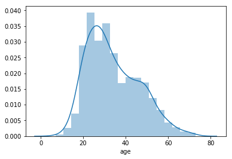

```python
data2 = User['age']
sns.distplot(data2)
```

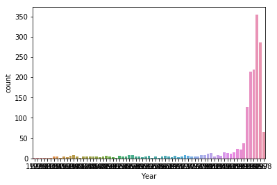

```python
sns.countplot(x="Year", data=Item)
```

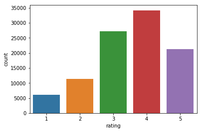

```python
sns.countplot(x="rating", data=Data)
```

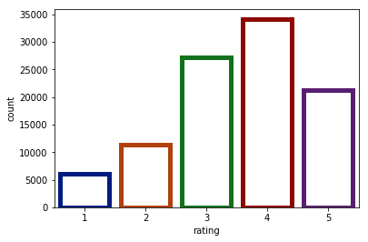

```python
sns.countplot(x="rating", data=Data,
                   facecolor=(0, 0, 0, 0),
                   linewidth=5,
                   edgecolor=sns.color_palette("dark", 5))
```

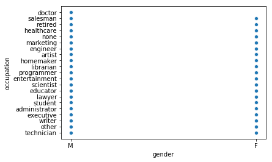

```python
# Using Scatter plot for the graph.
sns.scatterplot(data=User, x="gender", y="occupation")
```

### 8. Visualize how popularity of genres has changed over the years - 10 marks

Note that you need to use the **percent of number of releases in a year** as a parameter of popularity of a genre

Hint 1: You need to reach to a data frame where the release year is the index and the genre is the column names (one cell shows the number of release in a year in one genre) or vice versa. (Drop unnecessary column if there are any)

Hint 2: Find the total number of movies release in a year(use item dataset to get count of movies released in a particular year, store that value in a new column as 'total'). Now divide the value of each genre in that year by total to get percentage number of release in a particular year. `(df.div(df['total'], axis= 0) * 100)`

Once that is achieved, you can either use univariate plots or can use the heatmap to visualise all the changes over the years in one go.

Hint 3: Use groupby on the relevant column and use sum() on the same to find out the number of releases in a year/genre.

```python
#your code here
#Dropping the neccessary columns
New = Item.drop(['movie id','movie title','release date', 'Sum_of_Genre'], axis=1)
```

```python
#Made 'Year' the index of the dataframe
New.set_index('Year')
```

| Year | unknown | Action | Adventure | Animation | Childrens | Comedy | Crime | Documentary | Drama | Fantasy | Film-Noir | Horror | Musical | Mystery | Romance | Sci-Fi | Thriller | War | Western |
| --- | --- | --- | --- | --- | --- | --- | --- | --- | --- | --- | --- | --- | --- | --- | --- | --- | --- | --- | --- |
| 1995 | 0 | 0 | 0 | 1 | 1 | 1 | 0 | 0 | 0 | 0 | 0 | 0 | 0 | 0 | 0 | 0 | 0 | 0 | 0 |
| 1995 | 0 | 1 | 1 | 0 | 0 | 0 | 0 | 0 | 0 | 0 | 0 | 0 | 0 | 0 | 0 | 0 | 1 | 0 | 0 |
| 1995 | 0 | 0 | 0 | 0 | 0 | 0 | 0 | 0 | 0 | 0 | 0 | 0 | 0 | 0 | 0 | 0 | 1 | 0 | 0 |
| 1995 | 0 | 1 | 0 | 0 | 0 | 1 | 0 | 0 | 1 | 0 | 0 | 0 | 0 | 0 | 0 | 0 | 0 | 0 | 0 |
| 1995 | 0 | 0 | 0 | 0 | 0 | 0 | 1 | 0 | 1 | 0 | 0 | 0 | 0 | 0 | 0 | 0 | 1 | 0 | 0 |
| 1995 | 0 | 0 | 0 | 0 | 0 | 0 | 0 | 0 | 1 | 0 | 0 | 0 | 0 | 0 | 0 | 0 | 0 | 0 | 0 |
| 1995 | 0 | 0 | 0 | 0 | 0 | 0 | 0 | 0 | 1 | 0 | 0 | 0 | 0 | 0 | 0 | 1 | 0 | 0 | 0 |
| 1995 | 0 | 0 | 0 | 0 | 1 | 1 | 0 | 0 | 1 | 0 | 0 | 0 | 0 | 0 | 0 | 0 | 0 | 0 | 0 |
| 1995 | 0 | 0 | 0 | 0 | 0 | 0 | 0 | 0 | 1 | 0 | 0 | 0 | 0 | 0 | 0 | 0 | 0 | 0 | 0 |
| 1996 | 0 | 0 | 0 | 0 | 0 | 0 | 0 | 0 | 1 | 0 | 0 | 0 | 0 | 0 | 0 | 0 | 0 | 1 | 0 |
| 1995 | 0 | 0 | 0 | 0 | 0 | 0 | 1 | 0 | 0 | 0 | 0 | 0 | 0 | 0 | 0 | 0 | 1 | 0 | 0 |
| 1995 | 0 | 0 | 0 | 0 | 0 | 0 | 1 | 0 | 0 | 0 | 0 | 0 | 0 | 0 | 0 | 0 | 1 | 0 | 0 |
| 1995 | 0 | 0 | 0 | 0 | 0 | 1 | 0 | 0 | 0 | 0 | 0 | 0 | 0 | 0 | 0 | 0 | 0 | 0 | 0 |
| 1994 | 0 | 0 | 0 | 0 | 0 | 0 | 0 | 0 | 1 | 0 | 0 | 0 | 0 | 0 | 1 | 0 | 0 | 0 | 0 |
| 1996 | 0 | 0 | 0 | 0 | 0 | 0 | 0 | 0 | 1 | 0 | 0 | 0 | 0 | 0 | 0 | 0 | 0 | 0 | 0 |
| 1995 | 0 | 0 | 0 | 0 | 0 | 1 | 0 | 0 | 0 | 0 | 0 | 0 | 0 | 0 | 1 | 0 | 0 | 0 | 0 |
| 1996 | 0 | 1 | 0 | 0 | 0 | 1 | 1 | 0 | 0 | 0 | 0 | 1 | 0 | 0 | 0 | 0 | 1 | 0 | 0 |
| 1995 | 0 | 0 | 0 | 0 | 0 | 0 | 0 | 0 | 1 | 0 | 0 | 0 | 0 | 0 | 0 | 0 | 0 | 0 | 0 |
| 1995 | 0 | 0 | 0 | 0 | 0 | 0 | 0 | 0 | 1 | 0 | 0 | 0 | 0 | 0 | 0 | 0 | 0 | 0 | 0 |
| 1995 | 0 | 0 | 0 | 0 | 0 | 0 | 0 | 0 | 1 | 0 | 0 | 0 | 0 | 0 | 1 | 0 | 0 | 0 | 0 |
| 1996 | 0 | 1 | 1 | 0 | 0 | 1 | 0 | 0 | 0 | 0 | 0 | 0 | 1 | 0 | 0 | 0 | 1 | 0 | 0 |
| 1996 | 0 | 1 | 0 | 0 | 0 | 0 | 0 | 0 | 1 | 0 | 0 | 0 | 0 | 0 | 0 | 0 | 0 | 1 | 0 |
| 1996 | 0 | 0 | 0 | 0 | 0 | 0 | 0 | 0 | 1 | 0 | 0 | 0 | 0 | 0 | 0 | 0 | 1 | 0 | 0 |
| 1996 | 0 | 1 | 1 | 0 | 0 | 0 | 1 | 0 | 0 | 0 | 0 | 0 | 0 | 0 | 0 | 0 | 0 | 0 | 0 |
| 1996 | 0 | 0 | 0 | 0 | 0 | 1 | 0 | 0 | 0 | 0 | 0 | 0 | 0 | 0 | 0 | 0 | 0 | 0 | 0 |
| 1995 | 0 | 0 | 0 | 0 | 0 | 1 | 0 | 0 | 0 | 0 | 0 | 0 | 0 | 0 | 0 | 0 | 0 | 0 | 0 |
| 1995 | 0 | 1 | 0 | 0 | 0 | 0 | 0 | 0 | 0 | 0 | 0 | 0 | 0 | 0 | 0 | 0 | 0 | 0 | 0 |
| 1995 | 0 | 1 | 0 | 0 | 0 | 0 | 0 | 0 | 1 | 0 | 0 | 0 | 0 | 0 | 0 | 0 | 1 | 0 | 0 |
| 1995 | 0 | 1 | 1 | 0 | 0 | 1 | 1 | 0 | 0 | 0 | 0 | 0 | 0 | 0 | 0 | 0 | 0 | 0 | 0 |
| 1967 | 0 | 0 | 0 | 0 | 0 | 0 | 0 | 0 | 1 | 0 | 0 | 0 | 0 | 0 | 0 | 0 | 0 | 0 | 0 |
| ... | ... | ... | ... | ... | ... | ... | ... | ... | ... | ... | ... | ... | ... | ... | ... | ... | ... | ... | ... |
| 1996 | 0 | 0 | 0 | 0 | 0 | 0 | 0 | 0 | 1 | 0 | 0 | 0 | 0 | 0 | 0 | 0 | 0 | 0 | 0 |
| 1998 | 0 | 0 | 0 | 0 | 0 | 1 | 0 | 0 | 0 | 0 | 0 | 0 | 0 | 0 | 0 | 0 | 0 | 0 | 0 |
| 1994 | 0 | 0 | 0 | 0 | 0 | 1 | 0 | 0 | 0 | 0 | 0 | 0 | 0 | 0 | 1 | 0 | 0 | 0 | 0 |
| 1998 | 0 | 0 | 0 | 0 | 0 | 1 | 0 | 0 | 0 | 0 | 0 | 0 | 0 | 0 | 1 | 0 | 0 | 0 | 0 |
| 1996 | 0 | 1 | 0 | 0 | 0 | 0 | 0 | 0 | 1 | 0 | 0 | 0 | 0 | 0 | 0 | 0 | 0 | 0 | 0 |
| 1996 | 0 | 0 | 0 | 0 | 0 | 0 | 0 | 0 | 1 | 0 | 0 | 0 | 0 | 0 | 0 | 0 | 0 | 0 | 0 |
| 1996 | 0 | 0 | 0 | 0 | 0 | 1 | 0 | 0 | 0 | 0 | 0 | 0 | 0 | 0 | 0 | 0 | 0 | 0 | 0 |
| 1996 | 0 | 0 | 0 | 0 | 0 | 0 | 0 | 0 | 1 | 0 | 0 | 0 | 0 | 0 | 0 | 0 | 0 | 0 | 0 |
| 1994 | 0 | 0 | 0 | 0 | 0 | 0 | 0 | 0 | 1 | 0 | 0 | 0 | 0 | 0 | 0 | 0 | 0 | 0 | 0 |
| 1997 | 0 | 0 | 0 | 0 | 0 | 0 | 0 | 0 | 1 | 0 | 0 | 0 | 0 | 0 | 1 | 0 | 0 | 0 | 0 |
| 1997 | 0 | 0 | 0 | 0 | 0 | 0 | 0 | 0 | 1 | 0 | 0 | 0 | 0 | 0 | 0 | 0 | 0 | 1 | 0 |
| 1997 | 0 | 0 | 0 | 0 | 0 | 1 | 0 | 0 | 0 | 0 | 0 | 0 | 0 | 0 | 0 | 0 | 0 | 0 | 0 |
| 1997 | 0 | 0 | 0 | 0 | 0 | 0 | 0 | 0 | 1 | 0 | 0 | 0 | 0 | 0 | 0 | 0 | 0 | 0 | 0 |
| 1997 | 0 | 0 | 0 | 0 | 0 | 0 | 0 | 0 | 1 | 0 | 0 | 0 | 0 | 0 | 0 | 0 | 0 | 0 | 0 |
| 1997 | 0 | 0 | 0 | 0 | 0 | 0 | 0 | 0 | 1 | 0 | 0 | 0 | 0 | 0 | 0 | 0 | 0 | 0 | 0 |
| 1997 | 0 | 0 | 0 | 0 | 0 | 1 | 0 | 0 | 0 | 0 | 0 | 0 | 0 | 0 | 0 | 0 | 0 | 0 | 0 |
| 1997 | 0 | 0 | 0 | 0 | 0 | 0 | 1 | 0 | 1 | 0 | 0 | 0 | 0 | 1 | 0 | 0 | 0 | 0 | 0 |
| 1998 | 0 | 0 | 0 | 0 | 0 | 1 | 0 | 0 | 0 | 0 | 0 | 0 | 0 | 0 | 0 | 0 | 1 | 0 | 0 |
| 1998 | 0 | 0 | 0 | 0 | 0 | 0 | 0 | 0 | 1 | 0 | 0 | 0 | 0 | 0 | 0 | 0 | 0 | 0 | 0 |
| 1993 | 0 | 0 | 0 | 0 | 0 | 0 | 0 | 0 | 1 | 0 | 0 | 0 | 0 | 0 | 0 | 0 | 0 | 0 | 0 |
| 1995 | 0 | 1 | 0 | 0 | 0 | 0 | 0 | 0 | 0 | 0 | 0 | 0 | 0 | 0 | 0 | 0 | 1 | 0 | 0 |
| 1962 | 0 | 0 | 0 | 0 | 0 | 0 | 0 | 0 | 1 | 0 | 0 | 0 | 0 | 0 | 0 | 0 | 0 | 0 | 0 |
| 1996 | 0 | 0 | 0 | 0 | 0 | 0 | 0 | 0 | 1 | 0 | 0 | 0 | 0 | 0 | 0 | 0 | 0 | 0 | 0 |
| 1996 | 0 | 0 | 0 | 0 | 0 | 0 | 0 | 0 | 1 | 0 | 0 | 0 | 0 | 0 | 0 | 0 | 0 | 0 | 0 |
| 1996 | 0 | 0 | 0 | 0 | 0 | 0 | 0 | 0 | 1 | 0 | 0 | 0 | 0 | 0 | 0 | 0 | 0 | 0 | 0 |
| 1998 | 0 | 0 | 0 | 0 | 0 | 0 | 0 | 0 | 1 | 0 | 0 | 0 | 0 | 0 | 0 | 0 | 0 | 0 | 0 |
| 1998 | 0 | 0 | 0 | 0 | 0 | 0 | 0 | 0 | 0 | 0 | 0 | 0 | 0 | 0 | 1 | 0 | 1 | 0 | 0 |
| 1998 | 0 | 0 | 0 | 0 | 0 | 0 | 0 | 0 | 1 | 0 | 0 | 0 | 0 | 0 | 1 | 0 | 0 | 0 | 0 |
| 1994 | 0 | 0 | 0 | 0 | 0 | 1 | 0 | 0 | 0 | 0 | 0 | 0 | 0 | 0 | 0 | 0 | 0 | 0 | 0 |
| 1996 | 0 | 0 | 0 | 0 | 0 | 0 | 0 | 0 | 1 | 0 | 0 | 0 | 0 | 0 | 0 | 0 | 0 | 0 | 0 |

1681 rows × 19 columns

```python
#To structure the year accordingly - Lowest to the also latest year
genre_yr = Item[['Action', 'Adventure', 'Animation', 'Childrens','Comedy','Crime','Documentary','Drama','Fantasy','Film-Noir','Horror','Musical','Mystery','Romance','Sci-Fi','Thriller','War','Western','Year']].groupby('Year').sum()
genre_yr
```

| Year | Action | Adventure | Animation | Childrens | Comedy | Crime | Documentary | Drama | Fantasy | Film-Noir | Horror | Musical | Mystery | Romance | Sci-Fi | Thriller | War | Western |
| --- | --- | --- | --- | --- | --- | --- | --- | --- | --- | --- | --- | --- | --- | --- | --- | --- | --- | --- |
| 1922 | 0 | 0 | 0 | 0 | 0 | 0 | 0 | 0 | 0 | 0 | 1 | 0 | 0 | 0 | 0 | 0 | 0 | 0 |
| 1926 | 0 | 0 | 0 | 0 | 0 | 0 | 0 | 1 | 0 | 0 | 0 | 0 | 0 | 0 | 0 | 0 | 0 | 0 |
| 1930 | 0 | 0 | 0 | 0 | 0 | 0 | 0 | 1 | 0 | 0 | 0 | 0 | 0 | 0 | 0 | 0 | 0 | 0 |
| 1931 | 0 | 0 | 0 | 0 | 0 | 1 | 0 | 0 | 0 | 1 | 0 | 0 | 0 | 0 | 0 | 1 | 0 | 0 |
| 1932 | 0 | 0 | 0 | 0 | 0 | 0 | 0 | 0 | 0 | 0 | 0 | 0 | 0 | 1 | 0 | 0 | 1 | 0 |
| 1933 | 0 | 0 | 0 | 0 | 1 | 0 | 0 | 0 | 0 | 0 | 0 | 0 | 0 | 1 | 0 | 0 | 1 | 0 |
| 1934 | 0 | 0 | 0 | 0 | 2 | 0 | 0 | 1 | 0 | 0 | 0 | 1 | 1 | 1 | 0 | 0 | 0 | 0 |
| 1935 | 0 | 0 | 0 | 0 | 2 | 0 | 0 | 0 | 0 | 0 | 1 | 1 | 0 | 1 | 0 | 1 | 0 | 0 |
| 1936 | 0 | 0 | 0 | 0 | 1 | 0 | 0 | 1 | 0 | 0 | 0 | 0 | 0 | 0 | 0 | 0 | 0 | 0 |
| 1937 | 0 | 0 | 1 | 1 | 2 | 0 | 0 | 1 | 0 | 0 | 0 | 3 | 0 | 2 | 0 | 0 | 0 | 0 |
| 1938 | 1 | 1 | 0 | 0 | 1 | 0 | 0 | 1 | 0 | 0 | 0 | 0 | 0 | 0 | 0 | 0 | 0 | 0 |
| 1939 | 0 | 1 | 0 | 2 | 2 | 1 | 0 | 5 | 0 | 0 | 0 | 1 | 0 | 2 | 0 | 0 | 1 | 0 |
| 1940 | 0 | 1 | 2 | 2 | 3 | 0 | 0 | 0 | 0 | 0 | 0 | 1 | 0 | 2 | 0 | 2 | 0 | 0 |
| 1941 | 0 | 0 | 1 | 1 | 0 | 0 | 0 | 3 | 0 | 1 | 0 | 1 | 1 | 1 | 0 | 0 | 0 | 0 |
| 1942 | 0 | 0 | 0 | 0 | 1 | 0 | 0 | 2 | 0 | 0 | 0 | 0 | 0 | 1 | 0 | 0 | 2 | 0 |
| 1943 | 0 | 1 | 0 | 0 | 1 | 0 | 0 | 1 | 0 | 0 | 0 | 0 | 1 | 0 | 0 | 0 | 1 | 1 |
| 1944 | 0 | 0 | 0 | 0 | 1 | 1 | 0 | 0 | 0 | 2 | 0 | 1 | 3 | 0 | 0 | 3 | 0 | 0 |
| 1945 | 0 | 0 | 1 | 1 | 0 | 0 | 0 | 1 | 0 | 0 | 1 | 1 | 1 | 1 | 0 | 1 | 0 | 0 |
| 1946 | 0 | 0 | 0 | 0 | 0 | 1 | 0 | 3 | 0 | 2 | 0 | 0 | 1 | 1 | 0 | 1 | 0 | 0 |
| 1947 | 0 | 1 | 0 | 0 | 0 | 1 | 0 | 1 | 0 | 2 | 0 | 0 | 0 | 2 | 0 | 0 | 0 | 1 |
| 1948 | 0 | 1 | 0 | 0 | 0 | 1 | 0 | 0 | 0 | 2 | 0 | 0 | 0 | 0 | 0 | 1 | 0 | 0 |
| 1949 | 0 | 0 | 0 | 1 | 0 | 0 | 0 | 2 | 0 | 0 | 0 | 1 | 1 | 0 | 0 | 1 | 0 | 0 |
| 1950 | 0 | 0 | 1 | 2 | 1 | 0 | 0 | 3 | 0 | 1 | 0 | 1 | 1 | 0 | 0 | 0 | 0 | 0 |
| 1951 | 1 | 1 | 1 | 1 | 0 | 0 | 0 | 2 | 0 | 0 | 0 | 2 | 0 | 2 | 1 | 0 | 1 | 0 |
| 1952 | 0 | 0 | 0 | 0 | 1 | 0 | 0 | 0 | 0 | 0 | 0 | 1 | 0 | 2 | 0 | 0 | 0 | 1 |
| 1953 | 0 | 0 | 0 | 0 | 2 | 0 | 0 | 0 | 0 | 0 | 0 | 1 | 0 | 1 | 0 | 0 | 0 | 0 |
| 1954 | 1 | 1 | 0 | 1 | 2 | 0 | 0 | 3 | 1 | 0 | 0 | 0 | 2 | 1 | 1 | 2 | 0 | 1 |
| 1955 | 0 | 0 | 0 | 0 | 1 | 0 | 0 | 3 | 0 | 0 | 0 | 0 | 0 | 1 | 0 | 1 | 0 | 1 |
| 1956 | 0 | 1 | 0 | 0 | 1 | 0 | 0 | 2 | 0 | 0 | 0 | 0 | 0 | 0 | 1 | 0 | 0 | 0 |
| 1957 | 0 | 0 | 0 | 1 | 2 | 0 | 0 | 5 | 0 | 0 | 0 | 1 | 0 | 2 | 0 | 0 | 2 | 0 |
| ... | ... | ... | ... | ... | ... | ... | ... | ... | ... | ... | ... | ... | ... | ... | ... | ... | ... | ... |
| 1969 | 1 | 0 | 0 | 1 | 2 | 0 | 0 | 0 | 0 | 0 | 0 | 0 | 0 | 0 | 0 | 0 | 0 | 3 |
| 1970 | 0 | 0 | 1 | 1 | 1 | 0 | 0 | 1 | 0 | 0 | 0 | 0 | 0 | 0 | 0 | 0 | 2 | 0 |
| 1971 | 0 | 2 | 0 | 2 | 3 | 0 | 0 | 1 | 0 | 0 | 0 | 1 | 0 | 0 | 1 | 0 | 1 | 0 |
| 1972 | 1 | 0 | 0 | 0 | 1 | 1 | 0 | 2 | 0 | 0 | 0 | 0 | 0 | 0 | 0 | 0 | 0 | 0 |
| 1973 | 0 | 0 | 0 | 0 | 2 | 1 | 0 | 2 | 0 | 0 | 0 | 0 | 0 | 0 | 1 | 0 | 0 | 0 |
| 1974 | 1 | 1 | 0 | 1 | 4 | 1 | 0 | 2 | 0 | 1 | 2 | 0 | 1 | 0 | 0 | 1 | 0 | 0 |
| 1975 | 1 | 2 | 0 | 2 | 1 | 1 | 0 | 1 | 1 | 0 | 1 | 0 | 0 | 0 | 0 | 0 | 0 | 1 |
| 1976 | 0 | 0 | 0 | 0 | 0 | 0 | 0 | 2 | 0 | 0 | 3 | 0 | 0 | 0 | 0 | 0 | 0 | 0 |
| 1977 | 1 | 2 | 1 | 1 | 1 | 0 | 0 | 0 | 0 | 0 | 1 | 1 | 0 | 2 | 1 | 0 | 1 | 0 |
| 1978 | 1 | 0 | 0 | 0 | 2 | 0 | 0 | 1 | 0 | 0 | 1 | 1 | 0 | 1 | 0 | 0 | 1 | 0 |
| 1979 | 2 | 1 | 0 | 0 | 3 | 0 | 0 | 3 | 0 | 0 | 2 | 0 | 1 | 1 | 3 | 1 | 1 | 0 |
| 1980 | 2 | 1 | 0 | 0 | 3 | 0 | 0 | 3 | 0 | 0 | 2 | 1 | 0 | 2 | 1 | 0 | 1 | 0 |
| 1981 | 6 | 4 | 2 | 1 | 2 | 1 | 0 | 2 | 0 | 0 | 4 | 0 | 1 | 1 | 2 | 2 | 0 | 0 |
| 1982 | 1 | 1 | 0 | 1 | 3 | 0 | 0 | 6 | 1 | 1 | 2 | 3 | 0 | 1 | 3 | 0 | 1 | 0 |
| 1983 | 1 | 0 | 0 | 0 | 1 | 0 | 1 | 1 | 0 | 0 | 2 | 0 | 0 | 0 | 0 | 0 | 1 | 0 |
| 1984 | 2 | 1 | 0 | 0 | 1 | 1 | 0 | 5 | 0 | 0 | 1 | 1 | 1 | 0 | 2 | 2 | 1 | 0 |
| 1985 | 0 | 0 | 0 | 0 | 3 | 0 | 0 | 3 | 0 | 0 | 0 | 0 | 0 | 1 | 2 | 1 | 1 | 0 |
| 1986 | 5 | 3 | 1 | 1 | 3 | 0 | 0 | 8 | 0 | 0 | 2 | 0 | 0 | 2 | 3 | 2 | 3 | 0 |
| 1987 | 3 | 2 | 0 | 0 | 8 | 0 | 0 | 5 | 1 | 0 | 3 | 1 | 0 | 4 | 0 | 1 | 1 | 0 |
| 1988 | 2 | 2 | 2 | 1 | 3 | 0 | 1 | 3 | 0 | 0 | 0 | 0 | 0 | 2 | 1 | 3 | 0 | 1 |
| 1989 | 6 | 4 | 0 | 0 | 3 | 1 | 0 | 8 | 0 | 0 | 0 | 0 | 0 | 1 | 2 | 2 | 2 | 0 |
| 1990 | 7 | 1 | 0 | 1 | 6 | 3 | 2 | 12 | 0 | 1 | 1 | 0 | 0 | 4 | 0 | 4 | 0 | 2 |
| 1991 | 2 | 1 | 1 | 1 | 6 | 0 | 1 | 11 | 1 | 0 | 1 | 2 | 0 | 0 | 4 | 3 | 1 | 0 |
| 1992 | 8 | 1 | 2 | 1 | 12 | 5 | 0 | 14 | 0 | 0 | 6 | 1 | 1 | 7 | 3 | 5 | 2 | 1 |
| 1993 | 20 | 9 | 1 | 6 | 39 | 7 | 4 | 64 | 0 | 1 | 5 | 2 | 6 | 16 | 8 | 17 | 4 | 2 |
| 1994 | 30 | 13 | 4 | 15 | 82 | 8 | 9 | 97 | 3 | 0 | 8 | 2 | 2 | 35 | 7 | 25 | 7 | 6 |
| 1995 | 40 | 22 | 6 | 21 | 63 | 11 | 5 | 89 | 3 | 1 | 14 | 3 | 5 | 37 | 15 | 39 | 5 | 2 |
| 1996 | 44 | 24 | 9 | 21 | 108 | 21 | 18 | 170 | 6 | 1 | 11 | 9 | 6 | 38 | 15 | 47 | 9 | 2 |
| 1997 | 46 | 20 | 3 | 22 | 87 | 30 | 6 | 113 | 4 | 2 | 8 | 5 | 18 | 51 | 13 | 54 | 14 | 0 |
| 1998 | 12 | 3 | 0 | 1 | 13 | 7 | 3 | 33 | 1 | 2 | 4 | 1 | 3 | 11 | 5 | 18 | 0 | 0 |

71 rows × 18 columns

```python
#Calculate the total number of genre per year
total = New.groupby('Year')['Year'].count()
total
```

```
Year
1922      1
1926      1
1930      1
1931      1
1932      1
1933      2
1934      4
1935      4
1936      2
1937      4
1938      3
1939      7
1940      8
1941      5
```

[output cut: 48 more lines]

```python
genre_yr['total'] = pd.DataFrame(total)
genre_yr['total']
```

```
Year
1922      1
1926      1
1930      1
1931      1
1932      1
1933      2
1934      4
1935      4
1936      2
1937      4
1938      3
1939      7
1940      8
1941      5
```

[output cut: 48 more lines]

```python
Number_of_release_percent = (genre_yr.div(genre_yr['total'], axis= 0) * 100)
#Number_of_release_percent
```

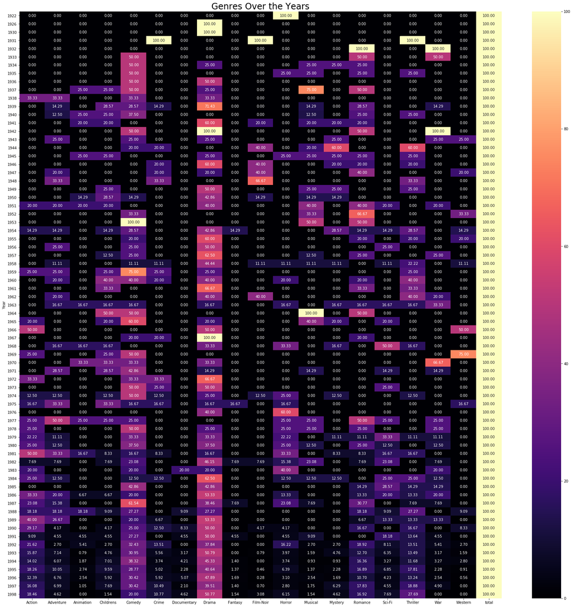

```python
#Plot heatmap to show result
fig,ax = plt.subplots(figsize=(30,30))
sns.heatmap(Number_of_release_percent, annot= True, ax=ax, fmt= '.2f',cmap="magma")
plt.title("Genres Over the Years", fontsize=24)
plt.show()
```

**Insights:** From the heatmap, drama has considerable good value across the years

### 9. Find the top 25 movies in terms of average ratings for movies that have been rated more than 100 times - 10 marks

Hints :

1. Find the count of ratings and average ratings for every movie.
2. Slice the movies which have ratings more than 100.
3. Sort values according to average rating such that movie which highest rating is on top.
4. Select top 25 movies.
5. You will have to use the .merge() function to get the movie titles.

Note: This question will need you to research about groupby and apply your findings. You can find more on groupby on https://realpython.com/pandas-groupby/.

```python
#your code here
Data.head(2)
```

|  | user id | movie id | rating | timestamp |
| --- | --- | --- | --- | --- |
| 0 | 196 | 242 | 3 | 881250949 |
| 1 | 186 | 302 | 3 | 891717742 |

```python
# Select the unique value
Data['rating'].nunique()
```

```
5
```

```python
# Count of ratings
Data['rating'].value_counts()
```

```
4    34174
3    27145
5    21201
2    11370
1     6110
Name: rating, dtype: int64
```

```python
# Average ratings for every movie.
Avg = Data[['movie id', 'rating']].groupby('movie id').mean().round()
Avg
```

| movie id | rating |
| --- | --- |
| 1 | 4.0 |
| 2 | 3.0 |
| 3 | 3.0 |
| 4 | 4.0 |
| 5 | 3.0 |
| 6 | 4.0 |
| 7 | 4.0 |
| 8 | 4.0 |
| 9 | 4.0 |
| 10 | 4.0 |
| 11 | 4.0 |
| 12 | 4.0 |
| 13 | 3.0 |
| 14 | 4.0 |
| 15 | 4.0 |
| 16 | 3.0 |
| 17 | 3.0 |
| 18 | 3.0 |
| 19 | 4.0 |
| 20 | 3.0 |
| 21 | 3.0 |
| 22 | 4.0 |
| 23 | 4.0 |
| 24 | 3.0 |
| 25 | 3.0 |
| 26 | 3.0 |
| 27 | 3.0 |
| 28 | 4.0 |
| 29 | 3.0 |
| 30 | 4.0 |
| ... | ... |
| 1653 | 5.0 |
| 1654 | 1.0 |
| 1655 | 2.0 |
| 1656 | 4.0 |
| 1657 | 3.0 |
| 1658 | 3.0 |
| 1659 | 1.0 |
| 1660 | 2.0 |
| 1661 | 1.0 |
| 1662 | 2.0 |
| 1663 | 2.0 |
| 1664 | 3.0 |
| 1665 | 2.0 |
| 1666 | 2.0 |
| 1667 | 3.0 |
| 1668 | 3.0 |
| 1669 | 2.0 |
| 1670 | 3.0 |
| 1671 | 1.0 |
| 1672 | 2.0 |
| 1673 | 3.0 |
| 1674 | 4.0 |
| 1675 | 3.0 |
| 1676 | 2.0 |
| 1677 | 3.0 |
| 1678 | 1.0 |
| 1679 | 3.0 |
| 1680 | 2.0 |
| 1681 | 3.0 |
| 1682 | 3.0 |

1682 rows × 1 columns

```python
# Slice the movies which have ratings more than 100
Maxi = Data[Data['movie id'] == Data['rating'] ]< 100
Maxi
```

|  | user id | movie id | rating | timestamp |
| --- | --- | --- | --- | --- |
| 170 | True | True | True | False |
| 264 | False | True | True | False |
| 2009 | False | True | True | False |
| 2073 | False | True | True | False |
| 3093 | False | True | True | False |
| 3201 | True | True | True | False |
| 3622 | False | True | True | False |
| 3916 | False | True | True | False |
| 4120 | False | True | True | False |
| 4617 | True | True | True | False |
| 6819 | True | True | True | False |
| 6823 | False | True | True | False |
| 7655 | True | True | True | False |
| 7698 | False | True | True | False |
| 8537 | False | True | True | False |
| 8719 | False | True | True | False |
| 8773 | False | True | True | False |
| 9415 | False | True | True | False |
| 10742 | False | True | True | False |
| 12293 | False | True | True | False |
| 12857 | False | True | True | False |
| 13498 | True | True | True | False |
| 13926 | False | True | True | False |
| 16768 | True | True | True | False |
| 17525 | False | True | True | False |
| 17623 | True | True | True | False |
| 18354 | False | True | True | False |
| 18826 | False | True | True | False |
| 20154 | False | True | True | False |
| 22435 | False | True | True | False |
| ... | ... | ... | ... | ... |
| 82042 | False | True | True | False |
| 82210 | False | True | True | False |
| 82559 | False | True | True | False |
| 83662 | False | True | True | False |
| 85015 | False | True | True | False |
| 85016 | False | True | True | False |
| 85140 | False | True | True | False |
| 85479 | False | True | True | False |
| 86046 | False | True | True | False |
| 86250 | False | True | True | False |
| 87447 | False | True | True | False |
| 87559 | False | True | True | False |
| 87690 | False | True | True | False |
| 88698 | False | True | True | False |
| 90297 | False | True | True | False |
| 90781 | False | True | True | False |
| 92676 | False | True | True | False |
| 93526 | False | True | True | False |
| 93603 | False | True | True | False |
| 94310 | False | True | True | False |
| 95507 | False | True | True | False |
| 96370 | False | True | True | False |
| 97142 | False | True | True | False |
| 97171 | False | True | True | False |
| 97368 | True | True | True | False |
| 97389 | False | True | True | False |
| 97456 | False | True | True | False |
| 97713 | False | True | True | False |
| 97912 | False | True | True | False |
| 98873 | False | True | True | False |

149 rows × 4 columns

```python
# Sort values according to average rating such that movie which highest rating is on top.
Highest_Order = Avg.sort_values(by = 'rating', ascending = False)
Highest_Order
```

| movie id | rating |
| --- | --- |
| 1122 | 5.0 |
| 1201 | 5.0 |
| 1599 | 5.0 |
| 1653 | 5.0 |
| 1189 | 5.0 |
| 1500 | 5.0 |
| 1449 | 5.0 |
| 1536 | 5.0 |
| 1467 | 5.0 |
| 1293 | 5.0 |
| 814 | 5.0 |
| 359 | 4.0 |
| 1012 | 4.0 |
| 1368 | 4.0 |
| 382 | 4.0 |
| 381 | 4.0 |
| 1158 | 4.0 |
| 1024 | 4.0 |
| 792 | 4.0 |
| 378 | 4.0 |
| 1159 | 4.0 |
| 793 | 4.0 |
| 1160 | 4.0 |
| 1375 | 4.0 |
| 794 | 4.0 |
| 615 | 4.0 |
| 1167 | 4.0 |
| 372 | 4.0 |
| 1021 | 4.0 |
| 1020 | 4.0 |
| ... | ... |
| 439 | 1.0 |
| 438 | 1.0 |
| 437 | 1.0 |
| 1287 | 1.0 |
| 424 | 1.0 |
| 858 | 1.0 |
| 1587 | 1.0 |
| 1586 | 1.0 |
| 1584 | 1.0 |
| 1583 | 1.0 |
| 1582 | 1.0 |
| 1581 | 1.0 |
| 1580 | 1.0 |
| 1577 | 1.0 |
| 1559 | 1.0 |
| 1576 | 1.0 |
| 1575 | 1.0 |
| 1574 | 1.0 |
| 1572 | 1.0 |
| 1571 | 1.0 |
| 1570 | 1.0 |
| 1569 | 1.0 |
| 1568 | 1.0 |
| 1567 | 1.0 |
| 1566 | 1.0 |
| 1565 | 1.0 |
| 1564 | 1.0 |
| 1563 | 1.0 |
| 1562 | 1.0 |
| 1420 | 1.0 |

1682 rows × 1 columns

```python
# Select top 25 movies
Highest_Order[0:26]
```

| movie id | rating |
| --- | --- |
| 1122 | 5.0 |
| 1201 | 5.0 |
| 1599 | 5.0 |
| 1653 | 5.0 |
| 1189 | 5.0 |
| 1500 | 5.0 |
| 1449 | 5.0 |
| 1536 | 5.0 |
| 1467 | 5.0 |
| 1293 | 5.0 |
| 814 | 5.0 |
| 359 | 4.0 |
| 1012 | 4.0 |
| 1368 | 4.0 |
| 382 | 4.0 |
| 381 | 4.0 |
| 1158 | 4.0 |
| 1024 | 4.0 |
| 792 | 4.0 |
| 378 | 4.0 |
| 1159 | 4.0 |
| 793 | 4.0 |
| 1160 | 4.0 |
| 1375 | 4.0 |
| 794 | 4.0 |
| 615 | 4.0 |

```python
# Merging Item dataframe and Data Dataframe
Movie_Id_Merge = pd.merge(Data, Item, on = 'movie id')
Movie_Id_Merge
```

|  | user id | movie id | rating | timestamp | movie title | release date | unknown | Action | Adventure | Animation | ... | Horror | Musical | Mystery | Romance | Sci-Fi | Thriller | War | Western | Sum_of_Genre | Year |
| --- | --- | --- | --- | --- | --- | --- | --- | --- | --- | --- | --- | --- | --- | --- | --- | --- | --- | --- | --- | --- | --- |
| 0 | 196 | 242 | 3 | 881250949 | Kolya | 1997-01-24 | 0 | 0 | 0 | 0 | ... | 0 | 0 | 0 | 0 | 0 | 0 | 0 | 0 | 1 | 1997 |
| 1 | 63 | 242 | 3 | 875747190 | Kolya | 1997-01-24 | 0 | 0 | 0 | 0 | ... | 0 | 0 | 0 | 0 | 0 | 0 | 0 | 0 | 1 | 1997 |
| 2 | 226 | 242 | 5 | 883888671 | Kolya | 1997-01-24 | 0 | 0 | 0 | 0 | ... | 0 | 0 | 0 | 0 | 0 | 0 | 0 | 0 | 1 | 1997 |
| 3 | 154 | 242 | 3 | 879138235 | Kolya | 1997-01-24 | 0 | 0 | 0 | 0 | ... | 0 | 0 | 0 | 0 | 0 | 0 | 0 | 0 | 1 | 1997 |
| 4 | 306 | 242 | 5 | 876503793 | Kolya | 1997-01-24 | 0 | 0 | 0 | 0 | ... | 0 | 0 | 0 | 0 | 0 | 0 | 0 | 0 | 1 | 1997 |
| 5 | 296 | 242 | 4 | 884196057 | Kolya | 1997-01-24 | 0 | 0 | 0 | 0 | ... | 0 | 0 | 0 | 0 | 0 | 0 | 0 | 0 | 1 | 1997 |
| 6 | 34 | 242 | 5 | 888601628 | Kolya | 1997-01-24 | 0 | 0 | 0 | 0 | ... | 0 | 0 | 0 | 0 | 0 | 0 | 0 | 0 | 1 | 1997 |
| 7 | 271 | 242 | 4 | 885844495 | Kolya | 1997-01-24 | 0 | 0 | 0 | 0 | ... | 0 | 0 | 0 | 0 | 0 | 0 | 0 | 0 | 1 | 1997 |
| 8 | 201 | 242 | 4 | 884110598 | Kolya | 1997-01-24 | 0 | 0 | 0 | 0 | ... | 0 | 0 | 0 | 0 | 0 | 0 | 0 | 0 | 1 | 1997 |
| 9 | 209 | 242 | 4 | 883589606 | Kolya | 1997-01-24 | 0 | 0 | 0 | 0 | ... | 0 | 0 | 0 | 0 | 0 | 0 | 0 | 0 | 1 | 1997 |
| 10 | 35 | 242 | 2 | 875459166 | Kolya | 1997-01-24 | 0 | 0 | 0 | 0 | ... | 0 | 0 | 0 | 0 | 0 | 0 | 0 | 0 | 1 | 1997 |
| 11 | 354 | 242 | 5 | 891180399 | Kolya | 1997-01-24 | 0 | 0 | 0 | 0 | ... | 0 | 0 | 0 | 0 | 0 | 0 | 0 | 0 | 1 | 1997 |
| 12 | 199 | 242 | 5 | 883782485 | Kolya | 1997-01-24 | 0 | 0 | 0 | 0 | ... | 0 | 0 | 0 | 0 | 0 | 0 | 0 | 0 | 1 | 1997 |
| 13 | 113 | 242 | 2 | 875075887 | Kolya | 1997-01-24 | 0 | 0 | 0 | 0 | ... | 0 | 0 | 0 | 0 | 0 | 0 | 0 | 0 | 1 | 1997 |
| 14 | 1 | 242 | 5 | 889751633 | Kolya | 1997-01-24 | 0 | 0 | 0 | 0 | ... | 0 | 0 | 0 | 0 | 0 | 0 | 0 | 0 | 1 | 1997 |
| 15 | 173 | 242 | 5 | 877556626 | Kolya | 1997-01-24 | 0 | 0 | 0 | 0 | ... | 0 | 0 | 0 | 0 | 0 | 0 | 0 | 0 | 1 | 1997 |
| 16 | 360 | 242 | 4 | 880353616 | Kolya | 1997-01-24 | 0 | 0 | 0 | 0 | ... | 0 | 0 | 0 | 0 | 0 | 0 | 0 | 0 | 1 | 1997 |
| 17 | 234 | 242 | 4 | 891033261 | Kolya | 1997-01-24 | 0 | 0 | 0 | 0 | ... | 0 | 0 | 0 | 0 | 0 | 0 | 0 | 0 | 1 | 1997 |
| 18 | 14 | 242 | 4 | 876964570 | Kolya | 1997-01-24 | 0 | 0 | 0 | 0 | ... | 0 | 0 | 0 | 0 | 0 | 0 | 0 | 0 | 1 | 1997 |
| 19 | 309 | 242 | 4 | 877370319 | Kolya | 1997-01-24 | 0 | 0 | 0 | 0 | ... | 0 | 0 | 0 | 0 | 0 | 0 | 0 | 0 | 1 | 1997 |
| 20 | 331 | 242 | 4 | 877196089 | Kolya | 1997-01-24 | 0 | 0 | 0 | 0 | ... | 0 | 0 | 0 | 0 | 0 | 0 | 0 | 0 | 1 | 1997 |
| 21 | 21 | 242 | 3 | 874951617 | Kolya | 1997-01-24 | 0 | 0 | 0 | 0 | ... | 0 | 0 | 0 | 0 | 0 | 0 | 0 | 0 | 1 | 1997 |
| 22 | 111 | 242 | 4 | 891679901 | Kolya | 1997-01-24 | 0 | 0 | 0 | 0 | ... | 0 | 0 | 0 | 0 | 0 | 0 | 0 | 0 | 1 | 1997 |
| 23 | 439 | 242 | 5 | 882892424 | Kolya | 1997-01-24 | 0 | 0 | 0 | 0 | ... | 0 | 0 | 0 | 0 | 0 | 0 | 0 | 0 | 1 | 1997 |
| 24 | 355 | 242 | 4 | 879486529 | Kolya | 1997-01-24 | 0 | 0 | 0 | 0 | ... | 0 | 0 | 0 | 0 | 0 | 0 | 0 | 0 | 1 | 1997 |
| 25 | 204 | 242 | 5 | 892388935 | Kolya | 1997-01-24 | 0 | 0 | 0 | 0 | ... | 0 | 0 | 0 | 0 | 0 | 0 | 0 | 0 | 1 | 1997 |
| 26 | 145 | 242 | 5 | 875269755 | Kolya | 1997-01-24 | 0 | 0 | 0 | 0 | ... | 0 | 0 | 0 | 0 | 0 | 0 | 0 | 0 | 1 | 1997 |
| 27 | 30 | 242 | 5 | 885941156 | Kolya | 1997-01-24 | 0 | 0 | 0 | 0 | ... | 0 | 0 | 0 | 0 | 0 | 0 | 0 | 0 | 1 | 1997 |
| 28 | 463 | 242 | 2 | 889935629 | Kolya | 1997-01-24 | 0 | 0 | 0 | 0 | ... | 0 | 0 | 0 | 0 | 0 | 0 | 0 | 0 | 1 | 1997 |
| 29 | 144 | 242 | 4 | 888103444 | Kolya | 1997-01-24 | 0 | 0 | 0 | 0 | ... | 0 | 0 | 0 | 0 | 0 | 0 | 0 | 0 | 1 | 1997 |
| ... | ... | ... | ... | ... | ... | ... | ... | ... | ... | ... | ... | ... | ... | ... | ... | ... | ... | ... | ... | ... | ... |
| 99961 | 405 | 1564 | 1 | 885546288 | To Cross the Rubicon | 1991-01-01 | 0 | 0 | 0 | 0 | ... | 0 | 0 | 0 | 0 | 0 | 0 | 0 | 0 | 1 | 1991 |
| 99962 | 456 | 1604 | 4 | 881372849 | He Walked by Night | 1948-01-01 | 0 | 0 | 0 | 0 | ... | 0 | 0 | 0 | 0 | 0 | 1 | 0 | 0 | 3 | 1948 |
| 99963 | 405 | 1574 | 1 | 885546529 | Pharaoh's Army | 1995-01-01 | 0 | 0 | 0 | 0 | ... | 0 | 0 | 0 | 0 | 0 | 0 | 1 | 0 | 1 | 1995 |
| 99964 | 883 | 1448 | 5 | 891695570 | My Favorite Season | 1996-04-19 | 0 | 0 | 0 | 0 | ... | 0 | 0 | 0 | 0 | 0 | 0 | 0 | 0 | 1 | 1996 |
| 99965 | 655 | 1448 | 3 | 887523224 | My Favorite Season | 1996-04-19 | 0 | 0 | 0 | 0 | ... | 0 | 0 | 0 | 0 | 0 | 0 | 0 | 0 | 1 | 1996 |
| 99966 | 234 | 1448 | 3 | 892335187 | My Favorite Season | 1996-04-19 | 0 | 0 | 0 | 0 | ... | 0 | 0 | 0 | 0 | 0 | 0 | 0 | 0 | 1 | 1996 |
| 99967 | 787 | 1671 | 1 | 888980193 | Further Gesture, A | 1998-02-20 | 0 | 0 | 0 | 0 | ... | 0 | 0 | 0 | 0 | 0 | 0 | 0 | 0 | 1 | 1998 |
| 99968 | 587 | 1625 | 4 | 892871732 | Nightwatch | 1997-04-22 | 0 | 0 | 0 | 0 | ... | 1 | 0 | 0 | 0 | 0 | 1 | 0 | 0 | 2 | 1997 |
| 99969 | 782 | 1665 | 2 | 891500194 | Brother's Kiss, A | 1997-04-25 | 0 | 0 | 0 | 0 | ... | 0 | 0 | 0 | 0 | 0 | 0 | 0 | 0 | 1 | 1997 |
| 99970 | 181 | 1325 | 1 | 878962816 | August | 1996-04-12 | 0 | 0 | 0 | 0 | ... | 0 | 0 | 0 | 0 | 0 | 0 | 0 | 0 | 1 | 1996 |
| 99971 | 782 | 1670 | 3 | 891497793 | Tainted | 1998-02-01 | 0 | 0 | 0 | 0 | ... | 0 | 0 | 0 | 0 | 0 | 1 | 0 | 0 | 2 | 1998 |
| 99972 | 181 | 1341 | 1 | 878962169 | Hedd Wyn | 1992-01-01 | 0 | 0 | 0 | 0 | ... | 0 | 0 | 0 | 0 | 0 | 0 | 0 | 0 | 1 | 1992 |
| 99973 | 181 | 1352 | 1 | 878962240 | Shadow of Angels (Schatten der Engel) | 1976-01-01 | 0 | 0 | 0 | 0 | ... | 0 | 0 | 0 | 0 | 0 | 0 | 0 | 0 | 1 | 1976 |
| 99974 | 655 | 1636 | 4 | 887473570 | Brothers in Trouble | 1996-04-26 | 0 | 0 | 0 | 0 | ... | 0 | 0 | 0 | 0 | 0 | 0 | 0 | 0 | 1 | 1996 |
| 99975 | 896 | 1681 | 3 | 887160722 | You So Crazy | 1994-01-01 | 0 | 0 | 0 | 0 | ... | 0 | 0 | 0 | 0 | 0 | 0 | 0 | 0 | 1 | 1994 |
| 99976 | 655 | 1638 | 3 | 887488947 | Normal Life | 1996-10-25 | 0 | 0 | 0 | 0 | ... | 0 | 0 | 0 | 0 | 0 | 0 | 0 | 0 | 2 | 1996 |
| 99977 | 782 | 1667 | 3 | 891500110 | Next Step, The | 1997-06-13 | 0 | 0 | 0 | 0 | ... | 0 | 0 | 0 | 0 | 0 | 0 | 0 | 0 | 1 | 1997 |
| 99978 | 851 | 1675 | 3 | 884222085 | Sunchaser, The | 1996-10-25 | 0 | 0 | 0 | 0 | ... | 0 | 0 | 0 | 0 | 0 | 0 | 0 | 0 | 1 | 1996 |
| 99979 | 234 | 1460 | 3 | 892335460 | Sleepover | 1996-10-25 | 0 | 0 | 0 | 0 | ... | 0 | 0 | 0 | 0 | 0 | 0 | 0 | 0 | 2 | 1996 |
| 99980 | 532 | 1594 | 4 | 893115576 | Everest | 1998-03-10 | 0 | 0 | 0 | 0 | ... | 0 | 0 | 0 | 0 | 0 | 0 | 0 | 0 | 1 | 1998 |
| 99981 | 416 | 1594 | 5 | 893212484 | Everest | 1998-03-10 | 0 | 0 | 0 | 0 | ... | 0 | 0 | 0 | 0 | 0 | 0 | 0 | 0 | 1 | 1998 |
| 99982 | 648 | 1626 | 1 | 884795447 | Nobody Loves Me (Keiner liebt mich) | 1996-02-09 | 0 | 0 | 0 | 0 | ... | 0 | 0 | 0 | 0 | 0 | 0 | 0 | 0 | 2 | 1996 |
| 99983 | 655 | 1645 | 4 | 892871225 | Butcher Boy, The | 1998-01-01 | 0 | 0 | 0 | 0 | ... | 0 | 0 | 0 | 0 | 0 | 0 | 0 | 0 | 1 | 1998 |
| 99984 | 747 | 1659 | 1 | 888733313 | Getting Away With Murder | 1996-04-12 | 0 | 0 | 0 | 0 | ... | 0 | 0 | 0 | 0 | 0 | 0 | 0 | 0 | 1 | 1996 |
| 99985 | 916 | 1682 | 3 | 880845755 | Scream of Stone (Schrei aus Stein) | 1996-03-08 | 0 | 0 | 0 | 0 | ... | 0 | 0 | 0 | 0 | 0 | 0 | 0 | 0 | 1 | 1996 |
| 99986 | 840 | 1674 | 4 | 891211682 | Mamma Roma | 1962-01-01 | 0 | 0 | 0 | 0 | ... | 0 | 0 | 0 | 0 | 0 | 0 | 0 | 0 | 1 | 1962 |
| 99987 | 655 | 1640 | 3 | 888474646 | Eighth Day, The | 1996-11-01 | 0 | 0 | 0 | 0 | ... | 0 | 0 | 0 | 0 | 0 | 0 | 0 | 0 | 1 | 1996 |
| 99988 | 655 | 1637 | 3 | 888984255 | Girls Town | 1996-08-23 | 0 | 0 | 0 | 0 | ... | 0 | 0 | 0 | 0 | 0 | 0 | 0 | 0 | 1 | 1996 |
| 99989 | 655 | 1630 | 3 | 887428735 | Silence of the Palace, The (Saimt el Qusur) | 1996-02-02 | 0 | 0 | 0 | 0 | ... | 0 | 0 | 0 | 0 | 0 | 0 | 0 | 0 | 1 | 1996 |
| 99990 | 655 | 1641 | 3 | 887427810 | Dadetown | 1996-09-18 | 0 | 0 | 0 | 0 | ... | 0 | 0 | 0 | 0 | 0 | 0 | 0 | 0 | 1 | 1996 |

99991 rows × 27 columns

### 10. Check for the validity of the below statements with respect to the data provided - 10 marks

- Men watch more drama than women
- Women watch more Sci-Fi than men
- Men watch more Romance than women

**compare the percentages**

**Please pay attention to what should be the denominator while calculating percentages**

1. Merge all the datasets
2. There is no need to conduct statistical tests around this. Just **compare the percentages** and comment on the validity of the above statements.
3. you might want ot use the .sum(), .div() function here.
4. Use number of ratings to validate the numbers. For example, if out of 4000 ratings received by women, 3000 are for drama, we will assume that 75% of the women watch drama.

```python
#your code here
# Merge all the datasets and added outer to carryout the union of the dataset
Final_Merge = pd.merge(User, Movie_Id_Merge, on = 'user id', how = 'outer')
Final_Merge
```

|  | user id | age | gender | occupation | zip code | movie id | rating | timestamp | movie title | release date | ... | Horror | Musical | Mystery | Romance | Sci-Fi | Thriller | War | Western | Sum_of_Genre | Year |
| --- | --- | --- | --- | --- | --- | --- | --- | --- | --- | --- | --- | --- | --- | --- | --- | --- | --- | --- | --- | --- | --- |
| 0 | 1 | 24 | M | technician | 85711 | 242 | 5 | 889751633 | Kolya | 1997-01-24 | ... | 0 | 0 | 0 | 0 | 0 | 0 | 0 | 0 | 1 | 1997 |
| 1 | 1 | 24 | M | technician | 85711 | 51 | 4 | 878543275 | Legends of the Fall | 1994-01-01 | ... | 0 | 0 | 0 | 1 | 0 | 0 | 1 | 1 | 4 | 1994 |
| 2 | 1 | 24 | M | technician | 85711 | 265 | 4 | 878542441 | Hunt for Red October, The | 1990-01-01 | ... | 0 | 0 | 0 | 0 | 0 | 1 | 0 | 0 | 2 | 1990 |
| 3 | 1 | 24 | M | technician | 85711 | 86 | 5 | 878543541 | Remains of the Day, The | 1993-01-01 | ... | 0 | 0 | 0 | 0 | 0 | 0 | 0 | 0 | 1 | 1993 |
| 4 | 1 | 24 | M | technician | 85711 | 257 | 4 | 874965954 | Men in Black | 1997-07-04 | ... | 0 | 0 | 0 | 0 | 1 | 0 | 0 | 0 | 4 | 1997 |
| 5 | 1 | 24 | M | technician | 85711 | 222 | 4 | 878873388 | Star Trek: First Contact | 1996-11-22 | ... | 0 | 0 | 0 | 0 | 1 | 0 | 0 | 0 | 3 | 1996 |
| 6 | 1 | 24 | M | technician | 85711 | 40 | 3 | 876893230 | To Wong Foo, Thanks for Everything! Julie Newmar | 1995-01-01 | ... | 0 | 0 | 0 | 0 | 0 | 0 | 0 | 0 | 1 | 1995 |
| 7 | 1 | 24 | M | technician | 85711 | 29 | 1 | 878542869 | Batman Forever | 1995-01-01 | ... | 0 | 0 | 0 | 0 | 0 | 0 | 0 | 0 | 4 | 1995 |
| 8 | 1 | 24 | M | technician | 85711 | 144 | 4 | 875073180 | Die Hard | 1988-01-01 | ... | 0 | 0 | 0 | 0 | 0 | 1 | 0 | 0 | 2 | 1988 |
| 9 | 1 | 24 | M | technician | 85711 | 118 | 3 | 875071927 | Twister | 1996-05-10 | ... | 0 | 0 | 0 | 0 | 0 | 1 | 0 | 0 | 3 | 1996 |
| 10 | 1 | 24 | M | technician | 85711 | 1 | 5 | 874965758 | Toy Story | 1995-01-01 | ... | 0 | 0 | 0 | 0 | 0 | 0 | 0 | 0 | 3 | 1995 |
| 11 | 1 | 24 | M | technician | 85711 | 95 | 4 | 875072303 | Aladdin | 1992-01-01 | ... | 0 | 1 | 0 | 0 | 0 | 0 | 0 | 0 | 4 | 1992 |
| 12 | 1 | 24 | M | technician | 85711 | 234 | 4 | 876892355 | Jaws | 1975-01-01 | ... | 1 | 0 | 0 | 0 | 0 | 0 | 0 | 0 | 2 | 1975 |
| 13 | 1 | 24 | M | technician | 85711 | 246 | 5 | 874965905 | Chasing Amy | 1997-01-01 | ... | 0 | 0 | 0 | 1 | 0 | 0 | 0 | 0 | 2 | 1997 |
| 14 | 1 | 24 | M | technician | 85711 | 98 | 4 | 875072404 | Silence of the Lambs, The | 1991-01-01 | ... | 0 | 0 | 0 | 0 | 0 | 1 | 0 | 0 | 2 | 1991 |
| 15 | 1 | 24 | M | technician | 85711 | 193 | 4 | 876892654 | Right Stuff, The | 1983-01-01 | ... | 0 | 0 | 0 | 0 | 0 | 0 | 0 | 0 | 1 | 1983 |
| 16 | 1 | 24 | M | technician | 85711 | 88 | 4 | 878542791 | Sleepless in Seattle | 1993-01-01 | ... | 0 | 0 | 0 | 1 | 0 | 0 | 0 | 0 | 2 | 1993 |
| 17 | 1 | 24 | M | technician | 85711 | 194 | 4 | 876892743 | Sting, The | 1973-01-01 | ... | 0 | 0 | 0 | 0 | 0 | 0 | 0 | 0 | 2 | 1973 |
| 18 | 1 | 24 | M | technician | 85711 | 32 | 5 | 888732909 | Crumb | 1994-01-01 | ... | 0 | 0 | 0 | 0 | 0 | 0 | 0 | 0 | 1 | 1994 |
| 19 | 1 | 24 | M | technician | 85711 | 16 | 5 | 878543541 | French Twist (Gazon maudit) | 1995-01-01 | ... | 0 | 0 | 0 | 1 | 0 | 0 | 0 | 0 | 2 | 1995 |
| 20 | 1 | 24 | M | technician | 85711 | 201 | 3 | 878542960 | Evil Dead II | 1987-01-01 | ... | 1 | 0 | 0 | 0 | 0 | 0 | 0 | 0 | 4 | 1987 |
| 21 | 1 | 24 | M | technician | 85711 | 241 | 4 | 878543133 | Last of the Mohicans, The | 1992-01-01 | ... | 0 | 0 | 0 | 1 | 0 | 0 | 1 | 0 | 3 | 1992 |
| 22 | 1 | 24 | M | technician | 85711 | 4 | 3 | 876893119 | Get Shorty | 1995-01-01 | ... | 0 | 0 | 0 | 0 | 0 | 0 | 0 | 0 | 3 | 1995 |
| 23 | 1 | 24 | M | technician | 85711 | 100 | 5 | 878543541 | Fargo | 1997-02-14 | ... | 0 | 0 | 0 | 0 | 0 | 1 | 0 | 0 | 3 | 1997 |
| 24 | 1 | 24 | M | technician | 85711 | 181 | 5 | 874965739 | Return of the Jedi | 1997-03-14 | ... | 0 | 0 | 0 | 1 | 1 | 0 | 1 | 0 | 5 | 1997 |
| 25 | 1 | 24 | M | technician | 85711 | 196 | 5 | 874965677 | Dead Poets Society | 1989-01-01 | ... | 0 | 0 | 0 | 0 | 0 | 0 | 0 | 0 | 1 | 1989 |
| 26 | 1 | 24 | M | technician | 85711 | 143 | 1 | 875072631 | Sound of Music, The | 1965-01-01 | ... | 0 | 1 | 0 | 0 | 0 | 0 | 0 | 0 | 1 | 1965 |
| 27 | 1 | 24 | M | technician | 85711 | 20 | 4 | 887431883 | Angels and Insects | 1995-01-01 | ... | 0 | 0 | 0 | 1 | 0 | 0 | 0 | 0 | 2 | 1995 |
| 28 | 1 | 24 | M | technician | 85711 | 219 | 1 | 878542327 | Nightmare on Elm Street, A | 1984-01-01 | ... | 1 | 0 | 0 | 0 | 0 | 0 | 0 | 0 | 1 | 1984 |
| 29 | 1 | 24 | M | technician | 85711 | 26 | 3 | 875072442 | Brothers McMullen, The | 1995-01-01 | ... | 0 | 0 | 0 | 0 | 0 | 0 | 0 | 0 | 1 | 1995 |
| ... | ... | ... | ... | ... | ... | ... | ... | ... | ... | ... | ... | ... | ... | ... | ... | ... | ... | ... | ... | ... | ... |
| 99961 | 943 | 22 | M | student | 77841 | 205 | 5 | 888639478 | Patton | 1970-01-01 | ... | 0 | 0 | 0 | 0 | 0 | 0 | 1 | 0 | 2 | 1970 |
| 99962 | 943 | 22 | M | student | 77841 | 42 | 5 | 888639042 | Clerks | 1994-01-01 | ... | 0 | 0 | 0 | 0 | 0 | 0 | 0 | 0 | 1 | 1994 |
| 99963 | 943 | 22 | M | student | 77841 | 808 | 4 | 888639868 | Program, The | 1993-01-01 | ... | 0 | 0 | 0 | 0 | 0 | 0 | 0 | 0 | 2 | 1993 |
| 99964 | 943 | 22 | M | student | 77841 | 470 | 4 | 888639814 | Tombstone | 1993-01-01 | ... | 0 | 0 | 0 | 0 | 0 | 0 | 0 | 1 | 1 | 1993 |
| 99965 | 943 | 22 | M | student | 77841 | 226 | 4 | 888639660 | Die Hard 2 | 1990-01-01 | ... | 0 | 0 | 0 | 0 | 0 | 1 | 0 | 0 | 2 | 1990 |
| 99966 | 943 | 22 | M | student | 77841 | 840 | 4 | 888693104 | Last Man Standing | 1996-09-20 | ... | 0 | 0 | 0 | 0 | 0 | 0 | 0 | 1 | 3 | 1996 |
| 99967 | 943 | 22 | M | student | 77841 | 1228 | 3 | 888640275 | Under Siege 2: Dark Territory | 1995-01-01 | ... | 0 | 0 | 0 | 0 | 0 | 0 | 0 | 0 | 1 | 1995 |
| 99968 | 943 | 22 | M | student | 77841 | 356 | 4 | 888639598 | Client, The | 1994-01-01 | ... | 0 | 0 | 1 | 0 | 0 | 1 | 0 | 0 | 3 | 1994 |
| 99969 | 943 | 22 | M | student | 77841 | 614 | 5 | 888639351 | Giant | 1956-01-01 | ... | 0 | 0 | 0 | 0 | 0 | 0 | 0 | 0 | 1 | 1956 |
| 99970 | 943 | 22 | M | student | 77841 | 139 | 1 | 888640027 | Love Bug, The | 1969-01-01 | ... | 0 | 0 | 0 | 0 | 0 | 0 | 0 | 0 | 2 | 1969 |
| 99971 | 943 | 22 | M | student | 77841 | 765 | 3 | 888640227 | Boomerang | 1992-01-01 | ... | 0 | 0 | 0 | 1 | 0 | 0 | 0 | 0 | 2 | 1992 |
| 99972 | 943 | 22 | M | student | 77841 | 67 | 4 | 888640143 | Ace Ventura: Pet Detective | 1994-01-01 | ... | 0 | 0 | 0 | 0 | 0 | 0 | 0 | 0 | 1 | 1994 |
| 99973 | 943 | 22 | M | student | 77841 | 31 | 4 | 888639066 | Crimson Tide | 1995-01-01 | ... | 0 | 0 | 0 | 0 | 0 | 1 | 1 | 0 | 3 | 1995 |
| 99974 | 943 | 22 | M | student | 77841 | 124 | 3 | 875501995 | Lone Star | 1996-06-21 | ... | 0 | 0 | 1 | 0 | 0 | 0 | 0 | 0 | 2 | 1996 |
| 99975 | 943 | 22 | M | student | 77841 | 570 | 1 | 888640125 | Wyatt Earp | 1994-01-01 | ... | 0 | 0 | 0 | 0 | 0 | 0 | 0 | 1 | 1 | 1994 |
| 99976 | 943 | 22 | M | student | 77841 | 816 | 4 | 888640186 | Candyman: Farewell to the Flesh | 1995-01-01 | ... | 1 | 0 | 0 | 0 | 0 | 0 | 0 | 0 | 1 | 1995 |
| 99977 | 943 | 22 | M | student | 77841 | 672 | 5 | 888640125 | Candyman | 1992-01-01 | ... | 1 | 0 | 0 | 0 | 0 | 0 | 0 | 0 | 1 | 1992 |
| 99978 | 943 | 22 | M | student | 77841 | 41 | 4 | 888640251 | Billy Madison | 1995-01-01 | ... | 0 | 0 | 0 | 0 | 0 | 0 | 0 | 0 | 1 | 1995 |
| 99979 | 943 | 22 | M | student | 77841 | 928 | 5 | 875502074 | Craft, The | 1996-04-26 | ... | 1 | 0 | 0 | 0 | 0 | 0 | 0 | 0 | 2 | 1996 |
| 99980 | 943 | 22 | M | student | 77841 | 549 | 1 | 888639772 | Rob Roy | 1995-01-01 | ... | 0 | 0 | 0 | 1 | 0 | 0 | 1 | 0 | 3 | 1995 |
| 99981 | 943 | 22 | M | student | 77841 | 391 | 2 | 888640291 | Last Action Hero | 1993-01-01 | ... | 0 | 0 | 0 | 0 | 0 | 0 | 0 | 0 | 2 | 1993 |
| 99982 | 943 | 22 | M | student | 77841 | 76 | 4 | 888639523 | Carlito's Way | 1993-01-01 | ... | 0 | 0 | 0 | 0 | 0 | 0 | 0 | 0 | 2 | 1993 |
| 99983 | 943 | 22 | M | student | 77841 | 722 | 3 | 888640208 | Nine Months | 1995-01-01 | ... | 0 | 0 | 0 | 0 | 0 | 0 | 0 | 0 | 1 | 1995 |
| 99984 | 943 | 22 | M | student | 77841 | 825 | 3 | 875502283 | Arrival, The | 1996-05-31 | ... | 0 | 0 | 0 | 0 | 1 | 1 | 0 | 0 | 3 | 1996 |
| 99985 | 943 | 22 | M | student | 77841 | 1074 | 4 | 888640250 | Reality Bites | 1994-01-01 | ... | 0 | 0 | 0 | 0 | 0 | 0 | 0 | 0 | 2 | 1994 |
| 99986 | 943 | 22 | M | student | 77841 | 1188 | 3 | 888640250 | Young Guns II | 1990-01-01 | ... | 0 | 0 | 0 | 0 | 0 | 0 | 0 | 1 | 3 | 1990 |
| 99987 | 943 | 22 | M | student | 77841 | 415 | 1 | 888640027 | Apple Dumpling Gang, The | 1975-01-01 | ... | 0 | 0 | 0 | 0 | 0 | 0 | 0 | 1 | 3 | 1975 |
| 99988 | 943 | 22 | M | student | 77841 | 373 | 3 | 888640275 | Judge Dredd | 1995-01-01 | ... | 0 | 0 | 0 | 0 | 1 | 0 | 0 | 0 | 3 | 1995 |
| 99989 | 943 | 22 | M | student | 77841 | 541 | 4 | 888639954 | Mortal Kombat | 1995-01-01 | ... | 0 | 0 | 0 | 0 | 0 | 0 | 0 | 0 | 2 | 1995 |
| 99990 | 943 | 22 | M | student | 77841 | 1330 | 3 | 888692465 | An Unforgettable Summer | 1994-01-01 | ... | 0 | 0 | 0 | 0 | 0 | 0 | 0 | 0 | 1 | 1994 |

99991 rows × 31 columns

```python
#Find out if there is an empty column
Final_Merge.isnull().values.any()
```

```
False
```

```python
gender_record = Final_Merge.groupby('gender')
gender_record.count()
```

| gender | user id | age | occupation | zip code | movie id | rating | timestamp | movie title | release date | unknown | ... | Horror | Musical | Mystery | Romance | Sci-Fi | Thriller | War | Western | Sum_of_Genre | Year |
| --- | --- | --- | --- | --- | --- | --- | --- | --- | --- | --- | --- | --- | --- | --- | --- | --- | --- | --- | --- | --- | --- |
| F | 25738 | 25738 | 25738 | 25738 | 25738 | 25738 | 25738 | 25738 | 25738 | 25738 | ... | 25738 | 25738 | 25738 | 25738 | 25738 | 25738 | 25738 | 25738 | 25738 | 25738 |
| M | 74253 | 74253 | 74253 | 74253 | 74253 | 74253 | 74253 | 74253 | 74253 | 74253 | ... | 74253 | 74253 | 74253 | 74253 | 74253 | 74253 | 74253 | 74253 | 74253 | 74253 |

2 rows × 30 columns

```python
gender_record2 = Final_Merge.groupby(['gender', 'Drama'])
gender_record2.count()
```

| gender | Drama | user id | age | occupation | zip code | movie id | rating | timestamp | movie title | release date | unknown | ... | Horror | Musical | Mystery | Romance | Sci-Fi | Thriller | War | Western | Sum_of_Genre | Year |
| --- | --- | --- | --- | --- | --- | --- | --- | --- | --- | --- | --- | --- | --- | --- | --- | --- | --- | --- | --- | --- | --- | --- |
| F | 0 | 14730 | 14730 | 14730 | 14730 | 14730 | 14730 | 14730 | 14730 | 14730 | 14730 | ... | 14730 | 14730 | 14730 | 14730 | 14730 | 14730 | 14730 | 14730 | 14730 | 14730 |
|  | 1 | 11008 | 11008 | 11008 | 11008 | 11008 | 11008 | 11008 | 11008 | 11008 | 11008 | ... | 11008 | 11008 | 11008 | 11008 | 11008 | 11008 | 11008 | 11008 | 11008 | 11008 |
| M | 0 | 45366 | 45366 | 45366 | 45366 | 45366 | 45366 | 45366 | 45366 | 45366 | 45366 | ... | 45366 | 45366 | 45366 | 45366 | 45366 | 45366 | 45366 | 45366 | 45366 | 45366 |
|  | 1 | 28887 | 28887 | 28887 | 28887 | 28887 | 28887 | 28887 | 28887 | 28887 | 28887 | ... | 28887 | 28887 | 28887 | 28887 | 28887 | 28887 | 28887 | 28887 | 28887 | 28887 |

4 rows × 29 columns

```python
gender_record3 = Final_Merge.groupby(['gender', 'Sci-Fi'])
gender_record3.count()
```

| gender | Sci-Fi | user id | age | occupation | zip code | movie id | rating | timestamp | movie title | release date | unknown | ... | Film-Noir | Horror | Musical | Mystery | Romance | Thriller | War | Western | Sum_of_Genre | Year |
| --- | --- | --- | --- | --- | --- | --- | --- | --- | --- | --- | --- | --- | --- | --- | --- | --- | --- | --- | --- | --- | --- | --- |
| F | 0 | 23109 | 23109 | 23109 | 23109 | 23109 | 23109 | 23109 | 23109 | 23109 | 23109 | ... | 23109 | 23109 | 23109 | 23109 | 23109 | 23109 | 23109 | 23109 | 23109 | 23109 |
|  | 1 | 2629 | 2629 | 2629 | 2629 | 2629 | 2629 | 2629 | 2629 | 2629 | 2629 | ... | 2629 | 2629 | 2629 | 2629 | 2629 | 2629 | 2629 | 2629 | 2629 | 2629 |
| M | 0 | 64152 | 64152 | 64152 | 64152 | 64152 | 64152 | 64152 | 64152 | 64152 | 64152 | ... | 64152 | 64152 | 64152 | 64152 | 64152 | 64152 | 64152 | 64152 | 64152 | 64152 |
|  | 1 | 10101 | 10101 | 10101 | 10101 | 10101 | 10101 | 10101 | 10101 | 10101 | 10101 | ... | 10101 | 10101 | 10101 | 10101 | 10101 | 10101 | 10101 | 10101 | 10101 | 10101 |

4 rows × 29 columns

```python
gender_record4 = Final_Merge.groupby(['gender', 'Romance'])
gender_record4.count()
```

| gender | Romance | user id | age | occupation | zip code | movie id | rating | timestamp | movie title | release date | unknown | ... | Film-Noir | Horror | Musical | Mystery | Sci-Fi | Thriller | War | Western | Sum_of_Genre | Year |
| --- | --- | --- | --- | --- | --- | --- | --- | --- | --- | --- | --- | --- | --- | --- | --- | --- | --- | --- | --- | --- | --- | --- |
| F | 0 | 19880 | 19880 | 19880 | 19880 | 19880 | 19880 | 19880 | 19880 | 19880 | 19880 | ... | 19880 | 19880 | 19880 | 19880 | 19880 | 19880 | 19880 | 19880 | 19880 | 19880 |
|  | 1 | 5858 | 5858 | 5858 | 5858 | 5858 | 5858 | 5858 | 5858 | 5858 | 5858 | ... | 5858 | 5858 | 5858 | 5858 | 5858 | 5858 | 5858 | 5858 | 5858 | 5858 |
| M | 0 | 60650 | 60650 | 60650 | 60650 | 60650 | 60650 | 60650 | 60650 | 60650 | 60650 | ... | 60650 | 60650 | 60650 | 60650 | 60650 | 60650 | 60650 | 60650 | 60650 | 60650 |
|  | 1 | 13603 | 13603 | 13603 | 13603 | 13603 | 13603 | 13603 | 13603 | 13603 | 13603 | ... | 13603 | 13603 | 13603 | 13603 | 13603 | 13603 | 13603 | 13603 | 13603 | 13603 |

4 rows × 29 columns